# Data Camp Correlation and Regression

Brian Linn

December 2018

# Visualizing Two Variables

## Scatterplots

Scatterplots are the most common and effective tools for visualizing the relationship between two numeric variables.

The ncbirths dataset is a random sample of 1,000 cases taken from a larger dataset collected in 2004. Each case describes the birth of a single child born in North Carolina, along with various characteristics of the child (e.g. birth weight, length of gestation, etc.), the child’s mother (e.g. age, weight gained during pregnancy, smoking habits, etc.) and the child’s father (e.g. age). You can view the help file for these data by running ?ncbirths in the console.

Using the ncbirths dataset, make a scatterplot using ggplot() to illustrate how the birth weight of these babies varies according to the number of weeks of gestation.

```r
data(ncbirths)
glimpse(ncbirths)
```

```
## Observations: 1,000
## Variables: 13
## $ fage           <int> NA, NA, 19, 21, NA, NA, 18, 17, NA, 20, 30, NA,...
## $ mage           <int> 13, 14, 15, 15, 15, 15, 15, 15, 16, 16, 16, 16,...
## $ mature         <fctr> younger mom, younger mom, younger mom, younger...
## $ weeks          <int> 39, 42, 37, 41, 39, 38, 37, 35, 38, 37, 45, 42,...
## $ premie         <fctr> full term, full term, full term, full term, fu...
## $ visits         <int> 10, 15, 11, 6, 9, 19, 12, 5, 9, 13, 9, 8, 4, 12...
## $ marital        <fctr> married, married, married, married, married, m...
## $ gained         <int> 38, 20, 38, 34, 27, 22, 76, 15, NA, 52, 28, 34,...
## $ weight         <dbl> 7.63, 7.88, 6.63, 8.00, 6.38, 5.38, 8.44, 4.69,...
## $ lowbirthweight <fctr> not low, not low, not low, not low, not low, l...
## $ gender         <fctr> male, male, female, male, female, male, male, ...
## $ habit          <fctr> nonsmoker, nonsmoker, nonsmoker, nonsmoker, no...
## $ whitemom       <fctr> not white, not white, white, white, not white,...
```

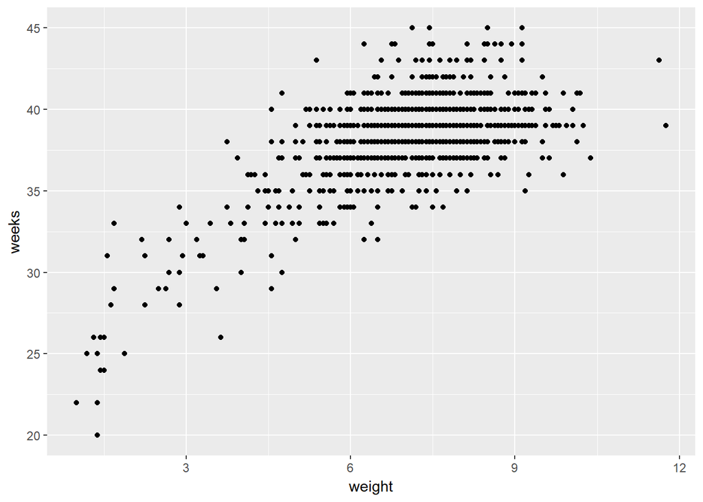

```r
ncbirths %>% ggplot(aes(x = weight, y = weeks)) +
        geom_point()
```

## Boxplots as discretized/conditioned scatterplots

If it is helpful, you can think of boxplots as scatterplots for which the variable on the x-axis has been discretized.

The cut() function takes two arguments: the continuous variable you want to discretize and the number of breaks that you want to make in that continuous variable in order to discretize it.

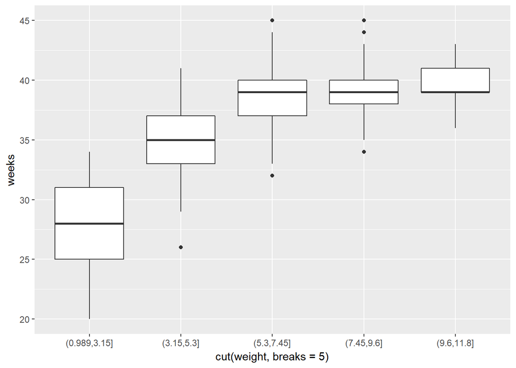

```r
ncbirths %>% ggplot(aes(x = cut(weight, breaks = 5), y = weeks)) +
        geom_boxplot()
```

## Creating scatterplots

Creating scatterplots is simple and they are so useful that is it worthwhile to expose yourself to many examples. Over time, you will gain familiarity with the types of patterns that you see. You will begin to recognize how scatterplots can reveal the nature of the relationship between two variables.

Instructions 100 XP Using the mammals dataset, create a scatterplot illustrating how the brain weight of a mammal varies as a function of its body weight. Using the mlbBat10 dataset, create a scatterplot illustrating how the slugging percentage (SLG) of a player varies as a function of his on-base percentage (OBP). Using the bdims dataset, create a scatterplot illustrating how a person’s weight varies as a function of their height. Use color to separate by sex, which you’ll need to coerce to a factor with factor(). Using the smoking dataset, create a scatterplot illustrating how the amount that a person smokes on weekdays varies as a function of their age.

```r
data(mammals)
glimpse(mammals)
```

```
## Observations: 62
## Variables: 11
## $ Species     <fctr> Africanelephant, Africangiantpouchedrat, ArcticFo...
## $ BodyWt      <dbl> 6654.000, 1.000, 3.385, 0.920, 2547.000, 10.550, 0...
## $ BrainWt     <dbl> 5712.0, 6.6, 44.5, 5.7, 4603.0, 179.5, 0.3, 169.0,...
## $ NonDreaming <dbl> NA, 6.3, NA, NA, 2.1, 9.1, 15.8, 5.2, 10.9, 8.3, 1...
## $ Dreaming    <dbl> NA, 2.0, NA, NA, 1.8, 0.7, 3.9, 1.0, 3.6, 1.4, 1.5...
## $ TotalSleep  <dbl> 3.3, 8.3, 12.5, 16.5, 3.9, 9.8, 19.7, 6.2, 14.5, 9...
## $ LifeSpan    <dbl> 38.6, 4.5, 14.0, NA, 69.0, 27.0, 19.0, 30.4, 28.0,...
## $ Gestation   <dbl> 645, 42, 60, 25, 624, 180, 35, 392, 63, 230, 112, ...
## $ Predation   <int> 3, 3, 1, 5, 3, 4, 1, 4, 1, 1, 5, 5, 2, 5, 1, 2, 2,...
## $ Exposure    <int> 5, 1, 1, 2, 5, 4, 1, 5, 2, 1, 4, 5, 1, 5, 1, 2, 2,...
## $ Danger      <int> 3, 3, 1, 3, 4, 4, 1, 4, 1, 1, 4, 5, 2, 5, 1, 2, 2,...
```

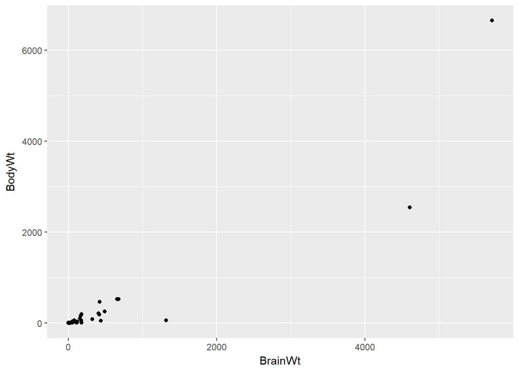

```r
mammals %>% ggplot(aes(x = BrainWt, BodyWt)) + geom_point()
```

```r
data("mlbBat10")
glimpse(mlbBat10)
```

```
## Observations: 1,199
## Variables: 19
## $ name     <fctr> I Suzuki, D Jeter, M Young, J Pierre, R Weeks, M Scu...
## $ team     <fctr> SEA, NYY, TEX, CWS, MIL, BOS, BAL, MIN, NYY, CIN, MI...
## $ position <fctr> OF, SS, 3B, OF, 2B, SS, OF, OF, 2B, 2B, OF, OF, 2B, ...
## $ G        <dbl> 162, 157, 157, 160, 160, 150, 160, 153, 160, 155, 157...
## $ AB       <dbl> 680, 663, 656, 651, 651, 632, 629, 629, 626, 626, 619...
## $ R        <dbl> 74, 111, 99, 96, 112, 92, 79, 85, 103, 100, 101, 103,...
## $ H        <dbl> 214, 179, 186, 179, 175, 174, 187, 166, 200, 172, 188...
## $ `2B`     <dbl> 30, 30, 36, 18, 32, 38, 45, 24, 41, 33, 45, 34, 41, 2...
## $ `3B`     <dbl> 3, 3, 3, 3, 4, 0, 3, 10, 3, 5, 1, 10, 4, 3, 3, 1, 5, ...
## $ HR       <dbl> 6, 10, 21, 1, 29, 11, 12, 3, 29, 18, 25, 4, 10, 25, 1...
## $ RBI      <dbl> 43, 67, 91, 47, 83, 56, 60, 58, 109, 59, 103, 41, 75,...
## $ TB       <dbl> 268, 245, 291, 206, 302, 245, 274, 219, 334, 269, 310...
## $ BB       <dbl> 45, 63, 50, 45, 76, 53, 73, 60, 57, 46, 56, 47, 28, 4...
## $ SO       <dbl> 86, 106, 115, 47, 184, 71, 93, 74, 77, 83, 105, 170, ...
## $ SB       <dbl> 42, 18, 4, 68, 11, 5, 7, 26, 3, 16, 14, 27, 14, 18, 1...
## $ CS       <dbl> 9, 5, 2, 18, 4, 4, 2, 4, 2, 12, 3, 6, 4, 9, 5, 1, 3, ...
## $ OBP      <dbl> 0.359, 0.340, 0.330, 0.341, 0.366, 0.333, 0.370, 0.33...
## $ SLG      <dbl> 0.394, 0.370, 0.444, 0.316, 0.464, 0.388, 0.436, 0.34...
## $ AVG      <dbl> 0.315, 0.270, 0.284, 0.275, 0.269, 0.275, 0.297, 0.26...
```

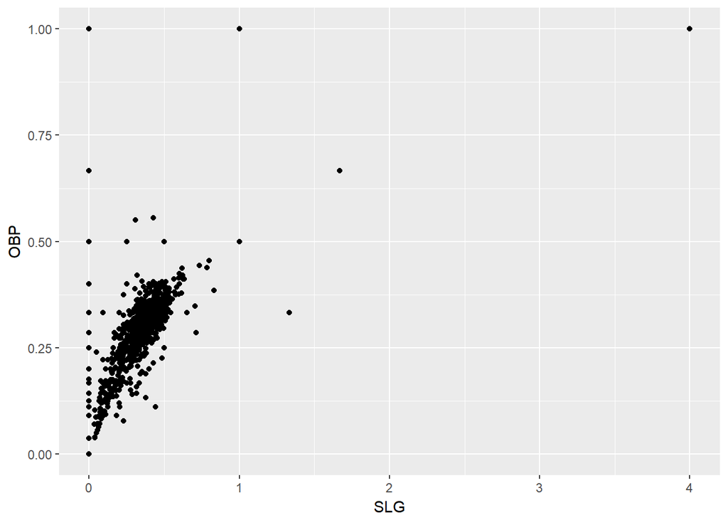

```r
mlbBat10 %>% ggplot(aes(x = SLG, y = OBP)) + geom_point()
```

```r
data(bdims)
glimpse(bdims)
```

```
## Observations: 507
## Variables: 25
## $ bia.di <dbl> 42.9, 43.7, 40.1, 44.3, 42.5, 43.3, 43.5, 44.4, 43.5, 4...
## $ bii.di <dbl> 26.0, 28.5, 28.2, 29.9, 29.9, 27.0, 30.0, 29.8, 26.5, 2...
## $ bit.di <dbl> 31.5, 33.5, 33.3, 34.0, 34.0, 31.5, 34.0, 33.2, 32.1, 3...
## $ che.de <dbl> 17.7, 16.9, 20.9, 18.4, 21.5, 19.6, 21.9, 21.8, 15.5, 2...
## $ che.di <dbl> 28.0, 30.8, 31.7, 28.2, 29.4, 31.3, 31.7, 28.8, 27.5, 2...
## $ elb.di <dbl> 13.1, 14.0, 13.9, 13.9, 15.2, 14.0, 16.1, 15.1, 14.1, 1...
## $ wri.di <dbl> 10.4, 11.8, 10.9, 11.2, 11.6, 11.5, 12.5, 11.9, 11.2, 1...
## $ kne.di <dbl> 18.8, 20.6, 19.7, 20.9, 20.7, 18.8, 20.8, 21.0, 18.9, 2...
## $ ank.di <dbl> 14.1, 15.1, 14.1, 15.0, 14.9, 13.9, 15.6, 14.6, 13.2, 1...
## $ sho.gi <dbl> 106.2, 110.5, 115.1, 104.5, 107.5, 119.8, 123.5, 120.4,...
## $ che.gi <dbl> 89.5, 97.0, 97.5, 97.0, 97.5, 99.9, 106.9, 102.5, 91.0,...
## $ wai.gi <dbl> 71.5, 79.0, 83.2, 77.8, 80.0, 82.5, 82.0, 76.8, 68.5, 7...
## $ nav.gi <dbl> 74.5, 86.5, 82.9, 78.8, 82.5, 80.1, 84.0, 80.5, 69.0, 8...
## $ hip.gi <dbl> 93.5, 94.8, 95.0, 94.0, 98.5, 95.3, 101.0, 98.0, 89.5, ...
## $ thi.gi <dbl> 51.5, 51.5, 57.3, 53.0, 55.4, 57.5, 60.9, 56.0, 50.0, 5...
## $ bic.gi <dbl> 32.5, 34.4, 33.4, 31.0, 32.0, 33.0, 42.4, 34.1, 33.0, 3...
## $ for.gi <dbl> 26.0, 28.0, 28.8, 26.2, 28.4, 28.0, 32.3, 28.0, 26.0, 2...
## $ kne.gi <dbl> 34.5, 36.5, 37.0, 37.0, 37.7, 36.6, 40.1, 39.2, 35.5, 3...
## $ cal.gi <dbl> 36.5, 37.5, 37.3, 34.8, 38.6, 36.1, 40.3, 36.7, 35.0, 3...
## $ ank.gi <dbl> 23.5, 24.5, 21.9, 23.0, 24.4, 23.5, 23.6, 22.5, 22.0, 2...
## $ wri.gi <dbl> 16.5, 17.0, 16.9, 16.6, 18.0, 16.9, 18.8, 18.0, 16.5, 1...
## $ age    <int> 21, 23, 28, 23, 22, 21, 26, 27, 23, 21, 23, 22, 20, 26,...
## $ wgt    <dbl> 65.6, 71.8, 80.7, 72.6, 78.8, 74.8, 86.4, 78.4, 62.0, 8...
## $ hgt    <dbl> 174.0, 175.3, 193.5, 186.5, 187.2, 181.5, 184.0, 184.5,...
## $ sex    <int> 1, 1, 1, 1, 1, 1, 1, 1, 1, 1, 1, 1, 1, 1, 1, 1, 1, 1, 1...
```

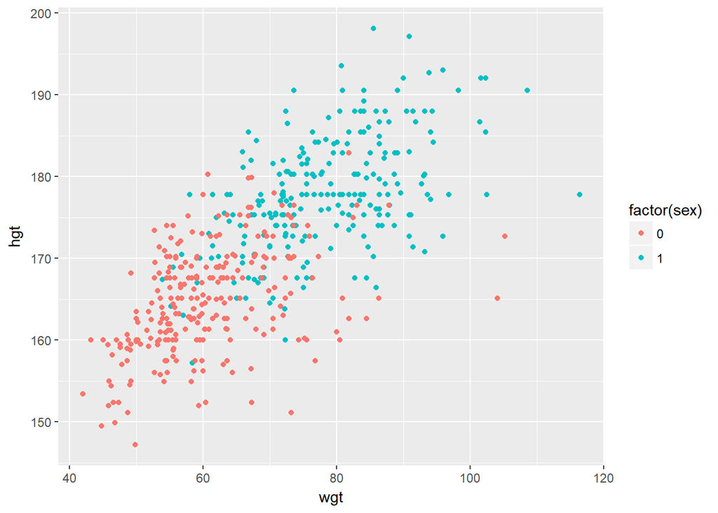

```r
bdims %>% ggplot(aes(x = wgt, y = hgt, color = factor(sex))) + geom_point()
```

```r
data(smoking)
glimpse(smoking)
```

```
## Observations: 1,691
## Variables: 12
## $ gender               <fctr> Male, Female, Male, Female, Female, Fema...
## $ age                  <int> 38, 42, 40, 40, 39, 37, 53, 44, 40, 41, 7...
## $ maritalStatus        <fctr> Divorced, Single, Married, Married, Marr...
## $ highestQualification <fctr> No Qualification, No Qualification, Degr...
## $ nationality          <fctr> British, British, English, English, Brit...
## $ ethnicity            <fctr> White, White, White, White, White, White...
## $ grossIncome          <fctr> 2,600 to 5,200, Under 2,600, 28,600 to 3...
## $ region               <fctr> The North, The North, The North, The Nor...
## $ smoke                <fctr> No, Yes, No, No, No, No, Yes, No, Yes, Y...
## $ amtWeekends          <int> NA, 12, NA, NA, NA, NA, 6, NA, 8, 15, NA,...
## $ amtWeekdays          <int> NA, 12, NA, NA, NA, NA, 6, NA, 8, 12, NA,...
## $ type                 <fctr> , Packets, , , , , Packets, , Hand-Rolle...
```

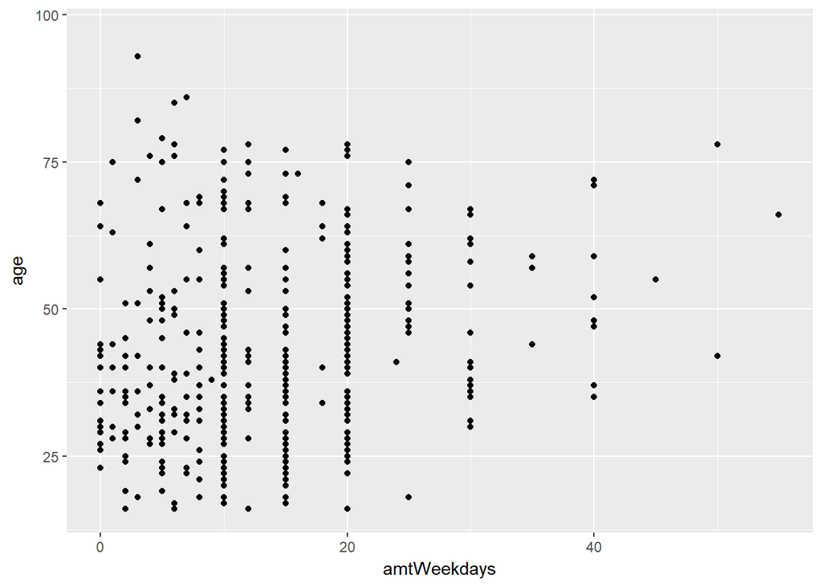

```r
smoking %>% ggplot(aes(x = amtWeekdays, y = age)) + geom_point()
```

## Transformations

The relationship between two variables may not be linear. In these cases we can sometimes see strange and even inscrutable patterns in a scatterplot of the data. Sometimes there really is no meaningful relationship between the two variables. Other times, a careful transformation of one or both of the variables can reveal a clear relationship.

Recall the bizarre pattern that you saw in the scatterplot between brain weight and body weight among mammals in a previous exercise. Can we use transformations to clarify this relationship?

ggplot2 provides several different mechanisms for viewing transformed relationships. The coord_trans() function transforms the coordinates of the plot. Alternatively, the scale_x_log10() and scale_y_log10() functions perform a base-10 log transformation of each axis. Note the differences in the appearance of the axes.

Instructions 100 XP The mammals dataset is available in your workspace.

Use coord_trans() to create a scatterplot showing how a mammal’s brain weight varies as a function of its body weight, where both the x and y axes are on a “log10” scale. Use scale_x_log10() and scale_y_log10() to achieve the same effect but with different axis labels and grid lines.

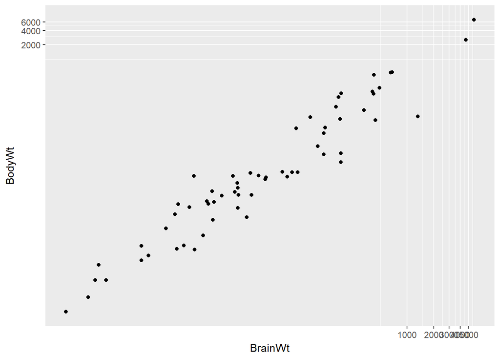

```r
data(mammals)
mammals %>%
  ggplot(aes(x = BrainWt, y = BodyWt)) +
  geom_point() +
  coord_trans(x = "log10", y= "log10")
```

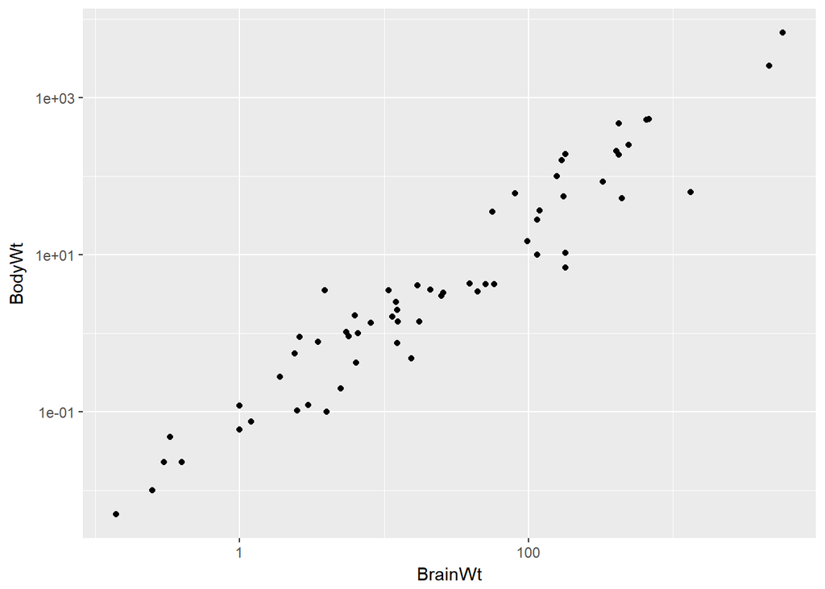

```r
mammals %>%
  ggplot(aes(x = BrainWt, y = BodyWt)) +
  geom_point() +
  scale_x_log10() +
  scale_y_log10()
```

## Identifying outliers

In Chapter 5, we will discuss how outliers can affect the results of a linear regression model and how we can deal with them. For now, it is enough to simply identify them and note how the relationship between two variables may change as a result of removing outliers.

Recall that in the baseball example earlier in the chapter, most of the points were clustered in the lower left corner of the plot, making it difficult to see the general pattern of the majority of the data. This difficulty was caused by a few outlying players whose on-base percentages (OBPs) were exceptionally high. These values are present in our dataset only because these players had very few batting opportunities.

Both OBP and SLG are known as rate statistics, since they measure the frequency of certain events (as opposed to their count). In order to compare these rates sensibly, it makes sense to include only players with a reasonable number of opportunities, so that these observed rates have the chance to approach their long-run frequencies.

In Major League Baseball, batters qualify for the batting title only if they have 3.1 plate appearances per game. This translates into roughly 502 plate appearances in a 162-game season. The mlbBat10 dataset does not include plate appearances as a variable, but we can use at-bats (AB) – which constitute a subset of plate appearances – as a proxy.

Instructions 100 XP Use filter() to create a scatterplot for SLG as a function of OBP among players who had at least 200 at-bats. Find the row of mlbBat10 corresponding to the one player with at least 200 at-bats whose OBP was below 0.200.

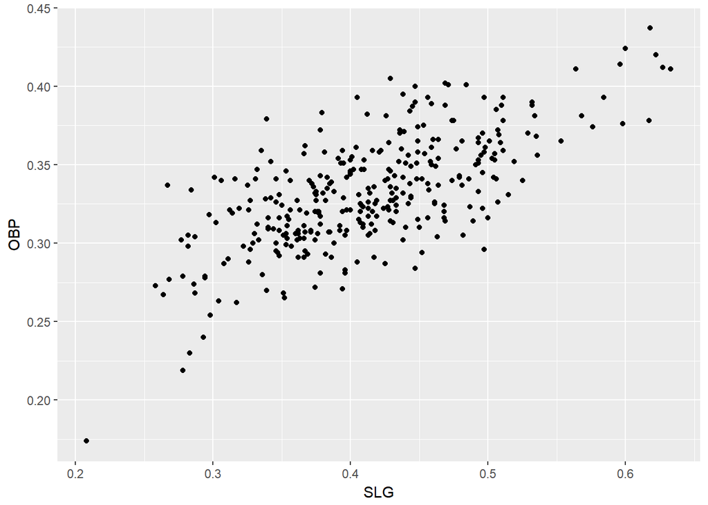

```r
data("mlbBat10")
mlbBat10 %>%
  filter(AB >= 200) %>%
  ggplot(aes(x = SLG, y = OBP)) +
  geom_point()
```

```r
mlbBat10 %>%
  filter(AB >= 200) %>%
  filter(OBP < 0.200)
```

```
##     name team position  G  AB  R  H 2B 3B HR RBI TB BB SO SB CS   OBP
## 1 B Wood  LAA       3B 81 226 20 33  2  0  4  14 47  6 71  1  0 0.174
##     SLG   AVG
## 1 0.208 0.146
```

# Correlation

correlation coefficient between -1 and 1 indicates strength of relationship between variables sign is the direction of relationship magnitude is the strength of relationship

Pearson product-moment correlation r(x,y) = cov(x,y)/sqrt(SXX * SYY) sxx - syy = sums of squares

```r
data("run10")
glimpse(run10)
```

```
## Observations: 16,924
## Variables: 9
## $ place    <dbl> 4494, 6298, 2502, 8176, 3413, 8008, 8791, 3987, 3451,...
## $ time     <dbl> 92.25, 106.35, 89.33, 113.50, 86.52, 112.30, 118.45, ...
## $ pace     <dbl> 9.225, 10.635, 8.933, 11.350, 8.652, 11.230, 11.845, ...
## $ age      <dbl> 38, 33, 55, 24, 54, 42, 36, 25, 25, 43, 55, 30, 39, 4...
## $ gender   <fctr> M, M, F, F, M, F, F, F, F, M, M, M, F, M, F, F, F, F...
## $ location <fctr> Chesapeake Beach MD, Washington DC, McLean VA, Alexa...
## $ state    <fctr> MD, DC, VA, VA, CA, MD, VA, VA, PA, MD, VA, MD, CA, ...
## $ divPlace <dbl> 690, 1322, 37, 878, 213, 785, 1215, 1230, 1074, 111, ...
## $ divTot   <dbl> 1093, 1490, 236, 974, 483, 974, 1367, 2782, 2782, 931...
```

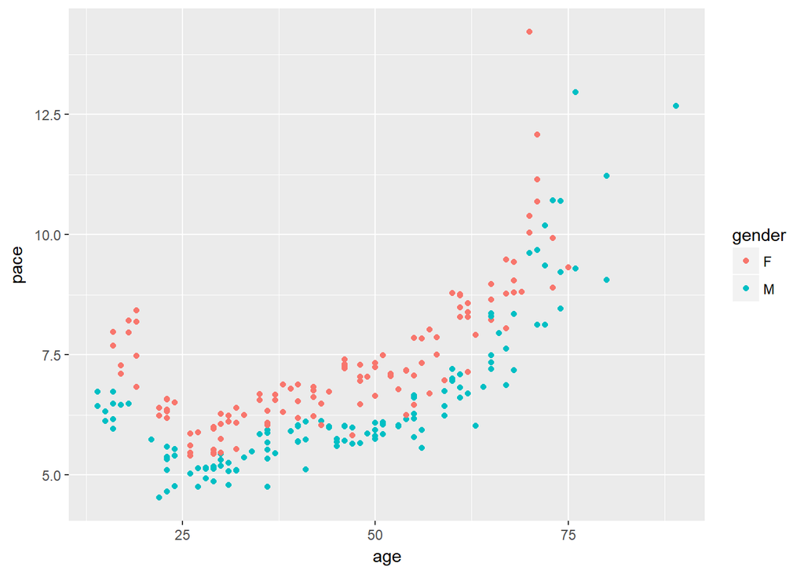

```r
run10 %>%
  filter(divPlace <= 10) %>%
  ggplot(aes(x = age, y = pace, color = gender)) +
  geom_point()
```

## Computing correlation

The cor(x, y) function will compute the Pearson product-moment correlation between variables, x and y. Since this quantity is symmetric with respect to x and y, it doesn’t matter in which order you put the variables.

At the same time, the cor() function is very conservative when it encounters missing data (e.g. NAs). The use argument allows you to override the default behavior of returning NA whenever any of the values encountered is NA. Setting the use argument to “pairwise.complete.obs” allows cor() to compute the correlation coefficient for those observations where the values of x and y are both not missing.

Instructions 100 XP Use cor() to compute the correlation between the birthweight of babies in the ncbirths dataset and their mother’s age. There is no missing data in either variable. Compute the correlation between the birthweight and the number of weeks of gestation for all non-missing pairs.

```r
data("ncbirths")
glimpse(ncbirths)
```

```
## Observations: 1,000
## Variables: 13
## $ fage           <int> NA, NA, 19, 21, NA, NA, 18, 17, NA, 20, 30, NA,...
## $ mage           <int> 13, 14, 15, 15, 15, 15, 15, 15, 16, 16, 16, 16,...
## $ mature         <fctr> younger mom, younger mom, younger mom, younger...
## $ weeks          <int> 39, 42, 37, 41, 39, 38, 37, 35, 38, 37, 45, 42,...
## $ premie         <fctr> full term, full term, full term, full term, fu...
## $ visits         <int> 10, 15, 11, 6, 9, 19, 12, 5, 9, 13, 9, 8, 4, 12...
## $ marital        <fctr> married, married, married, married, married, m...
## $ gained         <int> 38, 20, 38, 34, 27, 22, 76, 15, NA, 52, 28, 34,...
## $ weight         <dbl> 7.63, 7.88, 6.63, 8.00, 6.38, 5.38, 8.44, 4.69,...
## $ lowbirthweight <fctr> not low, not low, not low, not low, not low, l...
## $ gender         <fctr> male, male, female, male, female, male, male, ...
## $ habit          <fctr> nonsmoker, nonsmoker, nonsmoker, nonsmoker, no...
## $ whitemom       <fctr> not white, not white, white, white, not white,...
```

```r
# Compute correlation
ncbirths %>%
  summarize(N = n(), r = cor(weight, mage))
```

```
##      N          r
## 1 1000 0.05506589
```

```r
# Compute correlation for all non-missing pairs
ncbirths %>%
  summarize(N = n(), r = cor(weight, weeks, use = "pairwise.complete.obs"))
```

```
##      N         r
## 1 1000 0.6701013
```

## Anscombe Dataset

```r
data(anscombe)
summary(anscombe)
```

```
##        x1             x2             x3             x4
##  Min.   : 4.0   Min.   : 4.0   Min.   : 4.0   Min.   : 8
##  1st Qu.: 6.5   1st Qu.: 6.5   1st Qu.: 6.5   1st Qu.: 8
##  Median : 9.0   Median : 9.0   Median : 9.0   Median : 8
##  Mean   : 9.0   Mean   : 9.0   Mean   : 9.0   Mean   : 9
##  3rd Qu.:11.5   3rd Qu.:11.5   3rd Qu.:11.5   3rd Qu.: 8
##  Max.   :14.0   Max.   :14.0   Max.   :14.0   Max.   :19
##        y1               y2              y3              y4
##  Min.   : 4.260   Min.   :3.100   Min.   : 5.39   Min.   : 5.250
##  1st Qu.: 6.315   1st Qu.:6.695   1st Qu.: 6.25   1st Qu.: 6.170
##  Median : 7.580   Median :8.140   Median : 7.11   Median : 7.040
##  Mean   : 7.501   Mean   :7.501   Mean   : 7.50   Mean   : 7.501
##  3rd Qu.: 8.570   3rd Qu.:8.950   3rd Qu.: 7.98   3rd Qu.: 8.190
##  Max.   :10.840   Max.   :9.260   Max.   :12.74   Max.   :12.500
```

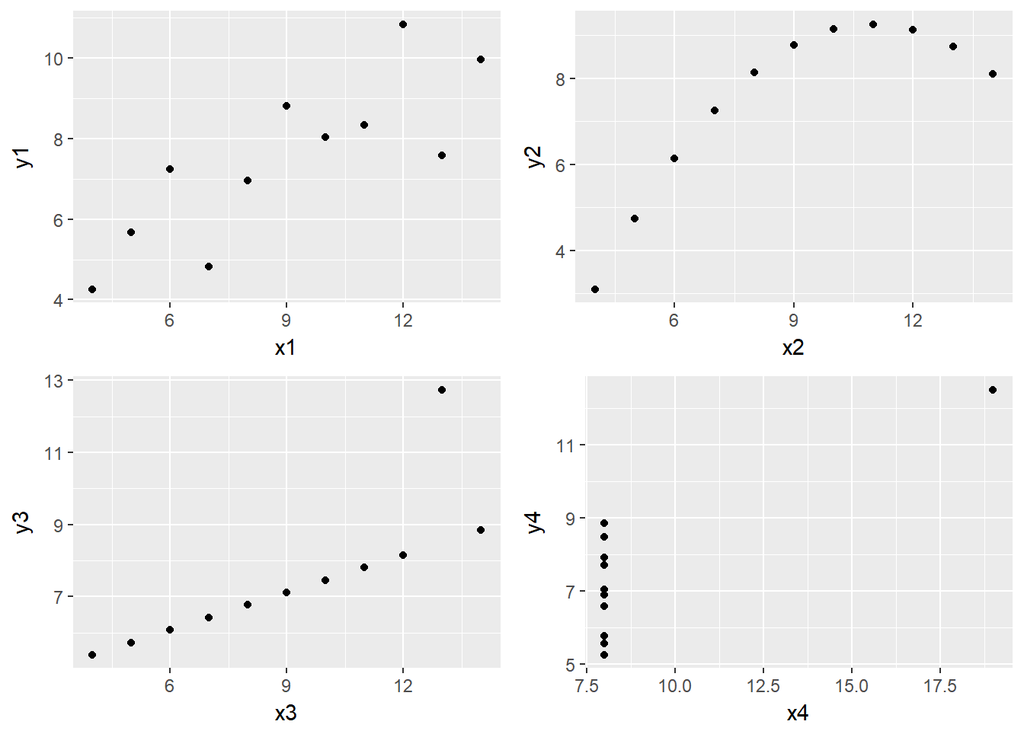

```r
plotx1 <- anscombe  %>%
  ggplot(aes(x = x1, y = y1)) +
  geom_point()
plotx2 <- anscombe  %>%
  ggplot(aes(x = x2, y = y2)) +
  geom_point()
plotx3 <- anscombe  %>%
  ggplot(aes(x = x3, y = y3)) +
  geom_point()
plotx4 <- anscombe  %>%
  ggplot(aes(x = x4, y = y4)) +
  geom_point()
grid.arrange(plotx1, plotx2, plotx3, plotx4)
```

```r
#the above dataset had all three "sets" from Anscombe across columns, so the gid.arrange takes the place of facet_wrap below

AnscombeDC <- read_csv("C:/Users/blinn/OneDrive - California Earthquake Authority/BI/R/statsDataCamp/AnscombeDC.csv")
```

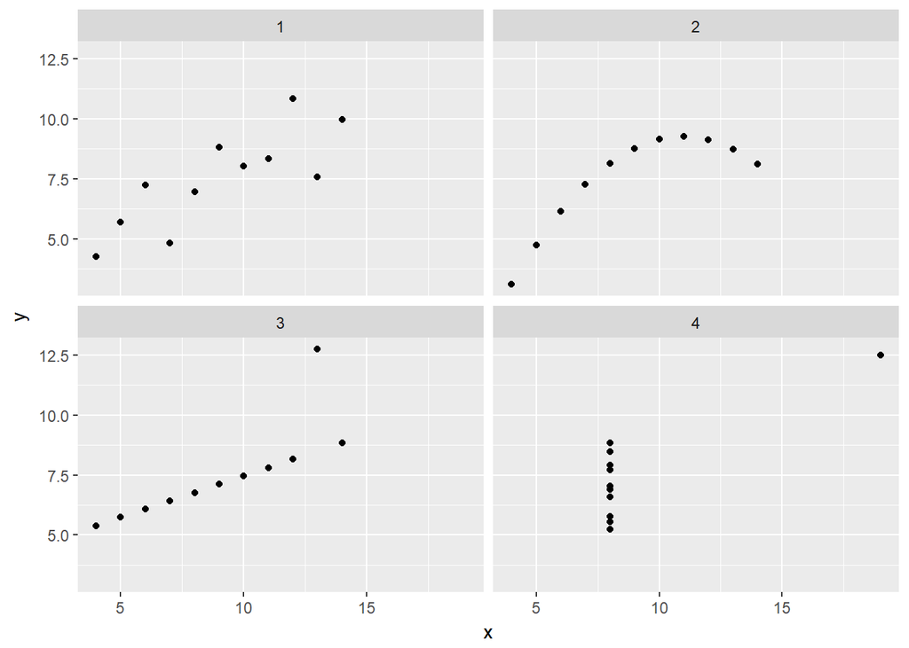

```r
AnscombeDC %>%
        ggplot(aes(x = x, y = y)) +
        geom_point() +
        facet_wrap(~ set)
```

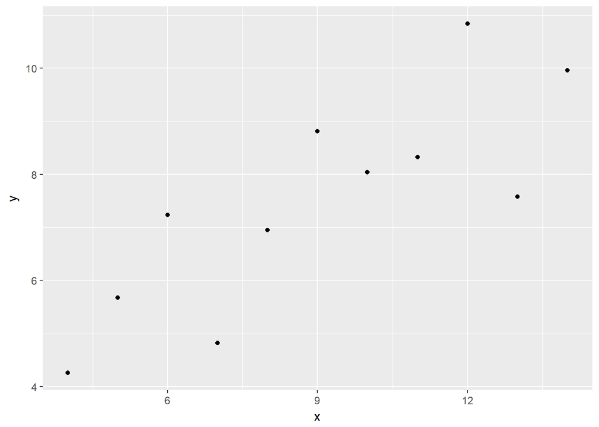

```r
AnscombeDC %>%
        filter(set ==1) %>%
        ggplot(aes(x = x, y = y)) +
        geom_point()
```

## Exploring Anscombe

In 1973, Francis Anscombe famously created four datasets with remarkably similar numerical properties, but obviously different graphic relationships. The Anscombe dataset contains the x and y coordinates for these four datasets, along with a grouping variable, set, that distinguishes the quartet.

It may be helpful to remind yourself of the graphic relationship by viewing the four scatterplots:

ggplot(data = Anscombe, aes(x = x, y = y)) + geom_point() + facet_wrap(~ set) Instructions 100 XP For each of the four sets of data points in the Anscombe dataset, compute the following in the order specified. Don’t worry about naming any of the variables other than the first in your call to summarize().

Number of observations, N Mean of x Standard deviation of x Mean of y Standard deviation of y Correlation coefficient between x and y

```r
# Compute properties of Anscombe
AnscombeDC %>%
        group_by(set) %>%
        summarize(N = n(),
                  meanX = mean(x),
                  sdX = sd(x),
                  meanY = mean(y),
                  sdY = sd(y),
                  corXY = cor(x, y)
                  )
```

```
## # A tibble: 4 x 7
##     set     N meanX   sdX meanY   sdY corXY
##   <int> <int> <dbl> <dbl> <dbl> <dbl> <dbl>
## 1     1    11  9.00  3.32  7.50  2.03 0.816
## 2     2    11  9.00  3.32  7.50  2.03 0.816
## 3     3    11  9.00  3.32  7.50  2.03 0.816
## 4     4    11  9.00  3.32  7.50  2.03 0.817
```

## Perception of correlation

Estimating the value of the correlation coefficient between two quantities from their scatterplot can be tricky. Statisticians have shown that people’s perception of the strength of these relationships can be influenced by design choices like the x and y scales.

Nevertheless, with some practice your perception of correlation will improve. Toggle through the four scatterplots in the plotting window, each of which you’ve seen in a previous exercise. Jot down your best estimate of the value of the correlation coefficient between each pair of variables. Then, compare these values to the actual values you compute in this exercise.

Instructions 100 XP Each graph in the plotting window corresponds to an instruction below. Compute the correlation between…

OBP and SLG for all players in the mlbBat10 dataset. OBP and SLG for all players in the mlbBat10 dataset with at least 200 at-bats. Height and weight for each sex in the bdims dataset. Body weight and brain weight for all species of mammals. Alongside this computation, compute the correlation between the same two quantities after taking their natural logarithms.

```r
# Correlation for all baseball players
mlbBat10 %>%
  summarize(N = n(), r = cor(OBP, SLG))
```

```
##      N         r
## 1 1199 0.8145628
```

```r
# Correlation for all players with at least 200 ABs
mlbBat10 %>%
  filter(AB >= 200) %>%
  summarize(N = n(), r = cor(OBP, SLG))
```

```
##     N         r
## 1 329 0.6855364
```

```r
# Correlation of body dimensions
bdims %>%
  group_by(sex) %>%
  summarize(N = n(), r = cor(hgt, wgt))
```

```
## # A tibble: 2 x 3
##     sex     N     r
##   <int> <int> <dbl>
## 1     0   260 0.431
## 2     1   247 0.535
```

```r
# Correlation among mammals, with and without log
mammals %>%
  summarize(N = n(),
            r = cor(BodyWt, BrainWt),
            r_log = cor(log(BodyWt), log(BrainWt)))
```

```
##    N         r     r_log
## 1 62 0.9341638 0.9595748
```

## Spurious correlation in random data

Statisticians must always be skeptical of potentially spurious correlations. Human beings are very good at seeing patterns in data, sometimes when the patterns themselves are actually just random noise. To illustrate how easy it can be to fall into this trap, we will look for patterns in truly random data.

The noise dataset contains 20 sets of x and y variables drawn at random from a standard normal distribution. Each set, denoted as z, has 50 observations of x, y pairs. Do you see any pairs of variables that might be meaningfully correlated? Are all of the correlation coefficients close to zero?

Instructions 100 XP Create a faceted scatterplot that shows the relationship between each of the 20 sets of pairs of random variables x and y. You will need the facet_wrap() function for this. Compute the actual correlation between each of the 20 sets of pairs of x and y. Identify the datasets that show non-trivial correlation of greater than 0.2 in absolute value.

```r
noiseDC <- read_csv("C:/Users/blinn/OneDrive - California Earthquake Authority/BI/R/statsDataCamp/noiseDC.csv")
glimpse(noiseDC)
```

```
## Observations: 1,000
## Variables: 3
## $ y <dbl> -1.20706575, 0.27742924, 1.08444118, -2.34569770, 0.42912469...
## $ x <dbl> -1.20533342, 0.30146674, -1.53914522, 0.63537072, 0.70295177...
## $ z <int> 1, 2, 3, 4, 5, 6, 7, 8, 9, 10, 11, 12, 13, 14, 15, 16, 17, 1...
```

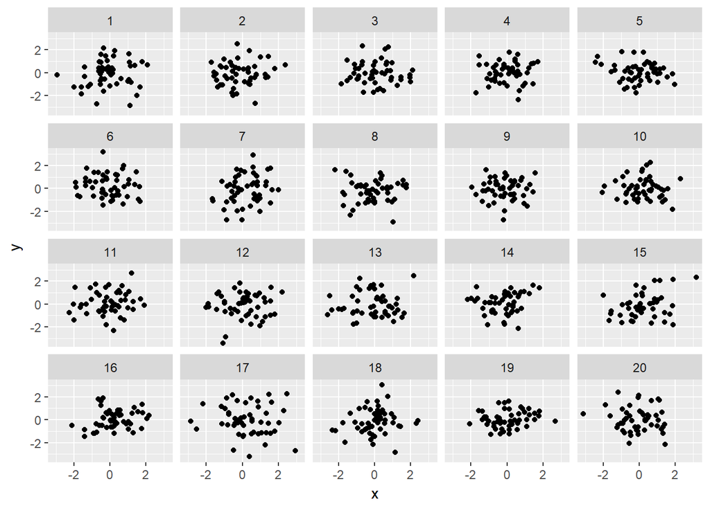

```r
# Create faceted scatterplot
noiseDC %>%
        ggplot(aes(x = x, y = y)) +
        geom_point() +
        facet_wrap(~ z)
```

```r
# Compute correlations for each dataset
noiseDC %>%
        group_by(z) %>%
        summarize(N = n(),
                  r = cor(x, y))
```

```
## # A tibble: 20 x 3
##        z     N        r
##    <int> <int>    <dbl>
##  1     1    50  0.122
##  2     2    50  0.0998
##  3     3    50 -0.0263
##  4     4    50  0.0650
##  5     5    50 -0.165
##  6     6    50 -0.0949
##  7     7    50  0.240
##  8     8    50  0.0110
##  9     9    50  0.00825
## 10    10    50 -0.0613
## 11    11    50  0.125
## 12    12    50  0.0667
## 13    13    50  0.0392
## 14    14    50  0.188
## 15    15    50  0.309
## 16    16    50  0.218
## 17    17    50 -0.103
## 18    18    50  0.139
## 19    19    50  0.165
## 20    20    50 -0.0926
```

```r
# Isolate sets with correlations above 0.2 in absolute strength
noiseDC_lowCor <- noiseDC %>%
        group_by(z) %>%
        summarize(N = n(),
                  r = cor(x, y)) %>%
        filter(abs(r) > 0.2)
noiseDC_lowCor
```

```
## # A tibble: 3 x 3
##       z     N     r
##   <int> <int> <dbl>
## 1     7    50 0.240
## 2    15    50 0.309
## 3    16    50 0.218
```

# Simple Linear Regression

After plotting the relationship between two variables, a line is drawn through the data to best fit the line to the data - minimize the deviation from the line across all points The best line is fit to the data according to the ‘Least Squares Criteria’ - the least squares regression line

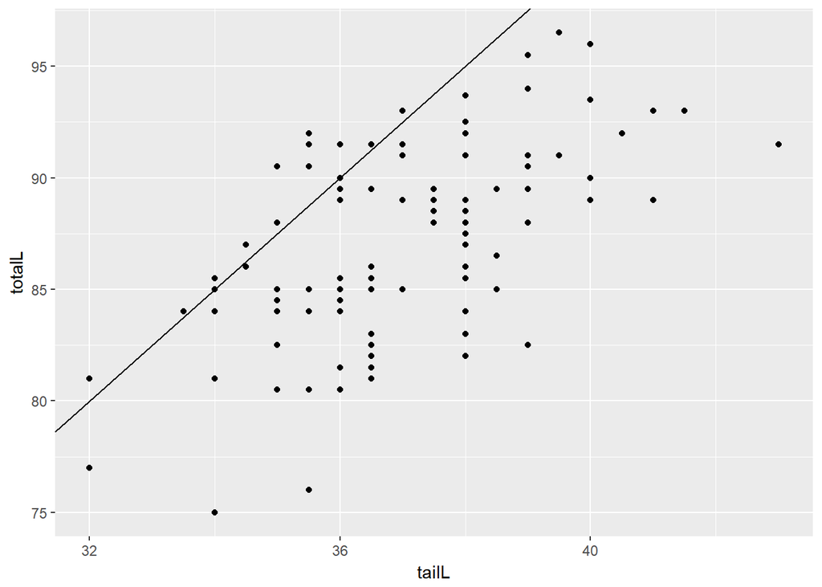

```r
data("possum")
#provides a 'good' fit as the line passes through the origin
possum %>%
        ggplot(aes(x = tailL,
                   y = totalL)) +
        geom_point() +
        geom_abline(intercept = 0, slope = 2.5)
```

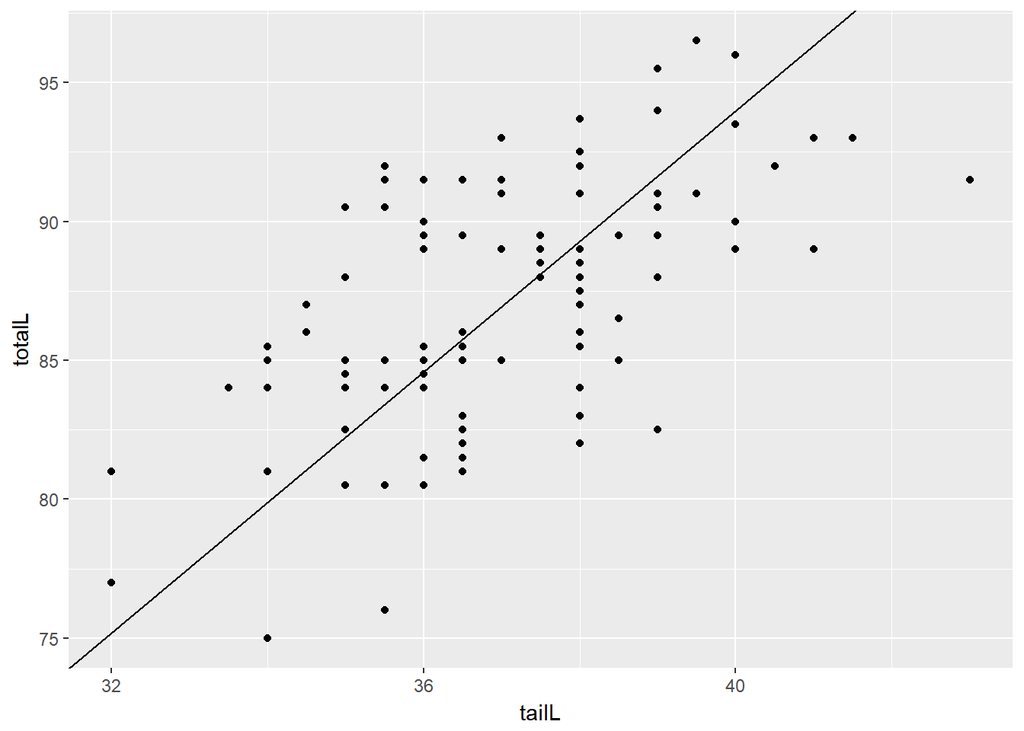

```r
#provides a 'better' fit as the line passes through the origin, but with a gentler slope
possum %>%
        ggplot(aes(x = tailL,
                   y = totalL)) +
        geom_point() +
        geom_abline(intercept = 0, slope = 2.35)
```

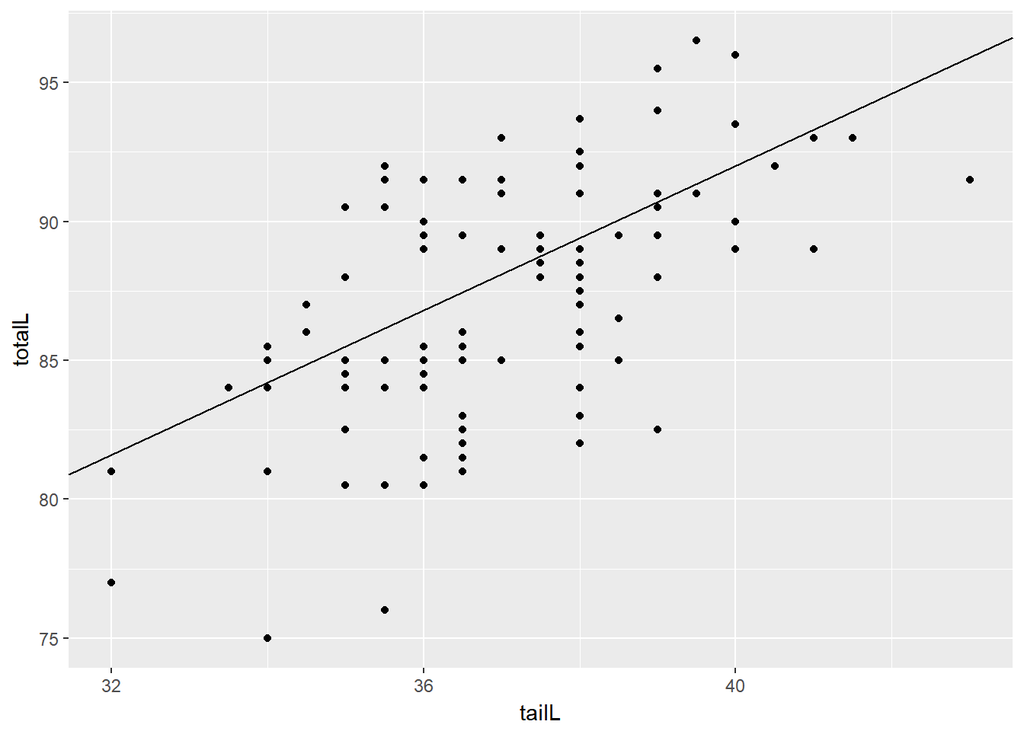

```r
#provides an even 'better' fit as the line no longer passes through the origin, and the slope is even gentler
possum %>%
        ggplot(aes(x = tailL,
                   y = totalL)) +
        geom_point() +
        geom_abline(intercept = 40, slope = 1.3)
```

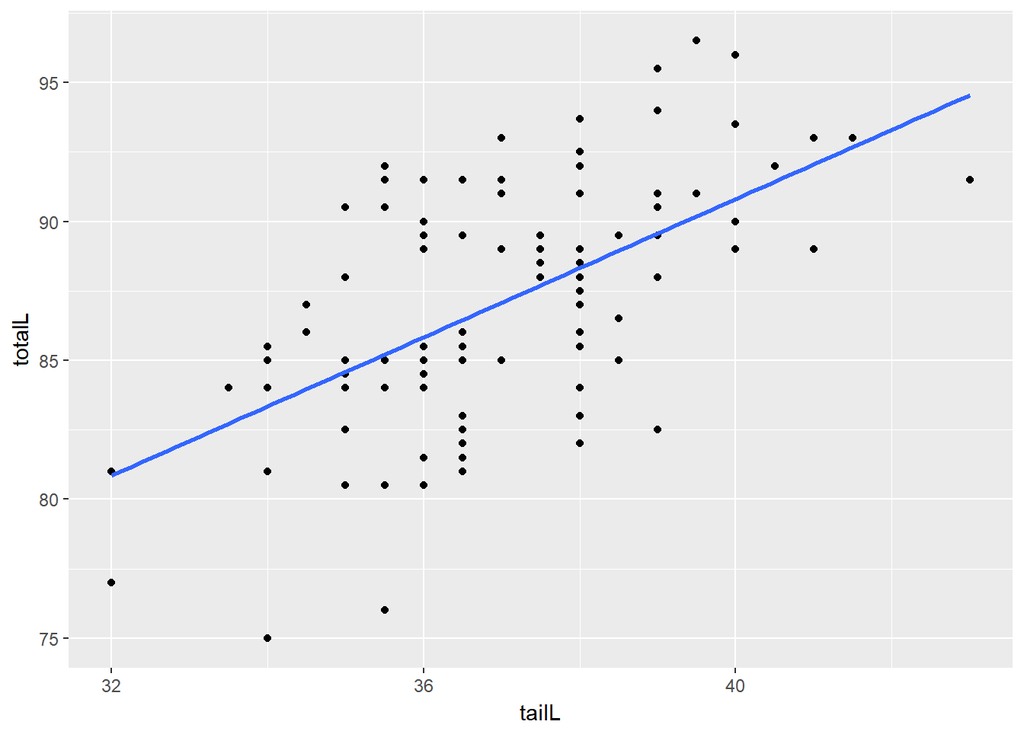

```r
#provides the 'best' fit as the line passes the data in a fashion to minimize the sqaure of distances from the line for all points
possum %>%
        ggplot(aes(x = tailL,
                   y = totalL)) +
        geom_point() +
        geom_smooth(method = "lm",
                    se = FALSE) #se controls the standard error shading presence on the line
```

## The “best fit” line

The simple linear regression model for a numeric response as a function of a numeric explanatory variable can be visualized on the corresponding scatterplot by a straight line. This is a “best fit” line that cuts through the data in a way that minimizes the distance between the line and the data points.

We might consider linear regression to be a specific example of a larger class of smooth models. The geom_smooth() function allows you to draw such models over a scatterplot of the data itself. This technique is known as visualizing the model in the data space. The method argument to geom_smooth() allows you to specify what class of smooth model you want to see. Since we are exploring linear models, we’ll set this argument to the value “lm”.

Note that geom_smooth() also takes an se argument that controls the standard error, which we will ignore for now.

Instructions 100 XP Create a scatterplot of body weight as a function of height for all individuals in the bdims dataset with a simple linear model plotted over the data.

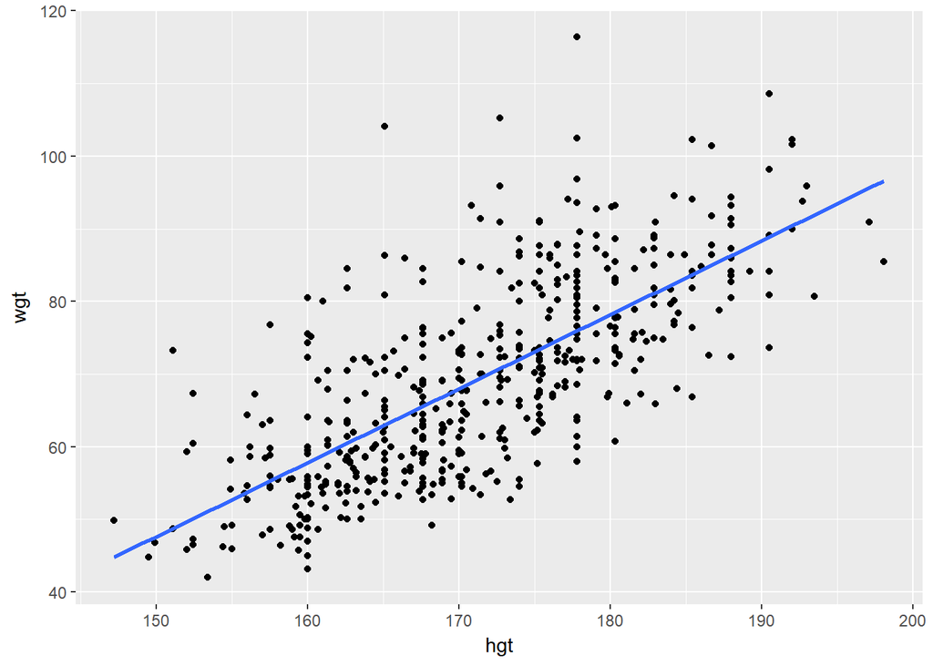

```r
data("bdims")
#glimpse(bdims)
# Scatterplot with regression line
bdims %>%
        ggplot(aes(x = hgt,
                   y = wgt)) +
        geom_point() +
        geom_smooth(method = "lm",
                    se = FALSE)
```

## Understanding the Linear Model

The linear model mathematically describes the relationship (best fit line) as function of the explanatory variable plus noise:

response = intercept + (slope * explanatory) + noise

$Y$ = $\beta_0$ + $\beta_1$ * $X_1$ + $\epsilon$, $\epsilon$ ~ $N(0,$ $\theta_e$)

intercept = $\beta_0$  
slope = $\beta_1$  
explanatory = $X_1$  
noise = $\epsilon$  
the noise is normally distributed with mean = 0, and sd = $\theta$

$Y$ = actual observed values

$\hat{Y}$ = expected value of response based on the model

$\hat{Y}$ = $\hat\beta_0$ + $\hat\beta_1$ * $X$

Residuals  
$e$ = $Y - \hat{Y}$

$\epsilon$ is an unknown true quantity while  
$e$ is a known estimate of that quantity

### Least Squares

- Easy, deterministic, unique solution
- Residuals sum to 0
- Line must pass through $(\bar{x}, \bar{y})$

### Key Concepts

- Y-hat is expected value given corresponding X
- Beta-hats are estimates of true, unknown betas
- Residuals (e’s) are estimates of true, unknown epsilons (noise)

$\widehat{poverty}$

```r
beta0 = 64.594
beta1 = .591
grad = 92.4
beta0 - (beta1 * grad)
```

```
## [1] 9.9856
```

```r
poverty = beta0 - (beta1 * grad)

poverty
```

```
## [1] 9.9856
```

## Fitting a linear model “by hand”

Second, the point (x¯,y¯) is always on the least squares regression line, where x¯ and y¯ denote the average of x and y, respectively.

The bdims_summary data frame contains all of the information you need to compute the slope and intercept of the least squares regression line for body weight (Y) as a function of height (X). You might need to do some algebra to solve for b0!

Instructions 100 XP Print the bdims_summary data frame. Use mutate() to add the slope and intercept to the bdims_summary data frame.

```r
bdims_summary <- read_csv("C:/Users/blinn/OneDrive - California Earthquake Authority/BI/R/statsDataCamp/bdims_summary.csv")
r <- bdims_summary["r"]
sy <- bdims_summary["sd_wgt"]
sx <- bdims_summary["sd_hgt"]
beta1 <- r * (sy/sx)
beta1
```

```
##          r
## 1 1.017617
```

```r
mean_hgt <- bdims_summary["mean_hgt"]
mean_wgt <- bdims_summary["mean_wgt"]
beta0 <- mean_wgt - (beta1 * mean_hgt)
beta0
```

```
##    mean_wgt
## 1 -105.0112
```

```r
# Print bdims_summary
bdims_summary
```

```
## # A tibble: 1 x 6
##       N     r mean_hgt sd_hgt mean_wgt sd_wgt
##   <int> <dbl>    <dbl>  <dbl>    <dbl>  <dbl>
## 1   507 0.717      171   9.41     69.1   13.3
```

```r
# Add slope and intercept
bdims_summary %>%
  mutate(slope = r * sd_wgt / sd_hgt,
         intercept = mean_wgt - slope * mean_hgt)
```

```
## # A tibble: 1 x 8
##       N     r mean_hgt sd_hgt mean_wgt sd_wgt slope intercept
##   <int> <dbl>    <dbl>  <dbl>    <dbl>  <dbl> <dbl>     <dbl>
## 1   507 0.717      171   9.41     69.1   13.3  1.02      -105
```

## Regression to the mean

Regression to the mean is a concept attributed to Sir Francis Galton. The basic idea is that extreme random observations will tend to be less extreme upon a second trial. This is simply due to chance alone. While “regression to the mean” and “linear regression” are not the same thing, we will examine them together in this exercise.

One way to see the effects of regression to the mean is to compare the heights of parents to their children’s heights. While it is true that tall mothers and fathers tend to have tall children, those children tend to be less tall than their parents, relative to average. That is, fathers who are 3 inches taller than the average father tend to have children who may be taller than average, but by less than 3 inches.

The Galton_men and Galton_women datasets contain data originally collected by Galton himself in the 1880s on the heights of men and women, respectively, along with their parents’ heights.

Compare the slope of the regression line to the slope of the diagonal line. What does this tell you?

Instructions 100 XP Create a scatterplot of the height of men as a function of their father’s height. Add the simple linear regression line and a diagonal line (with slope equal to 1 and intercept equal to 0) to the plot. Create a scatterplot of the height of women as a function of their mother’s height. Add the simple linear regression line and a diagonal line to the plot.

```r
#install.packages("HistData")
data("Galton")
Galton_men <- GaltonFamilies %>%
        filter(gender == "male")

Galton_women <- GaltonFamilies %>%
        filter(gender == "female")

glimpse(Galton_men)
```

```
## Observations: 481
## Variables: 8
## $ family          <fctr> 001, 002, 002, 003, 004, 004, 005, 005, 005, ...
## $ father          <dbl> 78.5, 75.5, 75.5, 75.0, 75.0, 75.0, 75.0, 75.0...
## $ mother          <dbl> 67.0, 66.5, 66.5, 64.0, 64.0, 64.0, 58.5, 58.5...
## $ midparentHeight <dbl> 75.43, 73.66, 73.66, 72.06, 72.06, 72.06, 69.0...
## $ children        <int> 4, 4, 4, 2, 5, 5, 6, 6, 6, 6, 6, 6, 6, 8, 8, 2...
## $ childNum        <int> 1, 1, 2, 1, 1, 2, 1, 2, 3, 1, 2, 3, 4, 1, 2, 1...
## $ gender          <fctr> male, male, male, male, male, male, male, mal...
## $ childHeight     <dbl> 73.2, 73.5, 72.5, 71.0, 70.5, 68.5, 72.0, 69.0...
```

```r
glimpse(Galton_women)
```

```
## Observations: 453
## Variables: 8
## $ family          <fctr> 001, 001, 001, 002, 002, 003, 004, 004, 004, ...
## $ father          <dbl> 78.5, 78.5, 78.5, 75.5, 75.5, 75.0, 75.0, 75.0...
## $ mother          <dbl> 67.0, 67.0, 67.0, 66.5, 66.5, 64.0, 64.0, 64.0...
## $ midparentHeight <dbl> 75.43, 75.43, 75.43, 73.66, 73.66, 72.06, 72.0...
## $ children        <int> 4, 4, 4, 4, 4, 2, 5, 5, 5, 6, 6, 6, 1, 6, 6, 3...
## $ childNum        <int> 2, 3, 4, 3, 4, 2, 3, 4, 5, 4, 5, 6, 1, 5, 6, 1...
## $ gender          <fctr> female, female, female, female, female, femal...
## $ childHeight     <dbl> 69.2, 69.0, 69.0, 65.5, 65.5, 68.0, 67.0, 64.5...
```

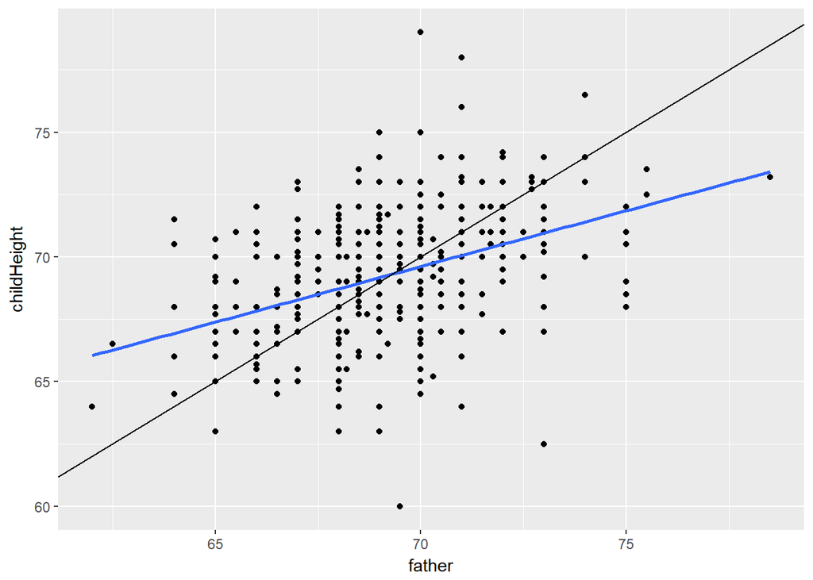

```r
Galton_men %>%
        ggplot(aes(x = father,
                          y = childHeight)) +
        geom_point() +
        geom_smooth(method = "lm",
                    se = FALSE) +
        geom_abline(slope = 1, intercept = 0)
```

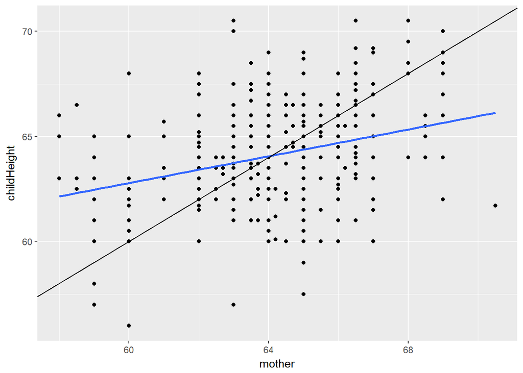

```r
Galton_women %>%
        ggplot(aes(x = mother,
                          y = childHeight)) +
        geom_point() +
        geom_smooth(method = "lm",
                    se = FALSE) +
        geom_abline(slope = 1, intercept = 0)
```

# Interpreting Regression Models

```r
#load textbook data
data("textbooks")
head(textbooks)
```

```
##   deptAbbr course           ibsn uclaNew amazNew more  diff
## 1   Am Ind   C170 978-0803272620   27.67   27.95    Y -0.28
## 2   Anthro      9 978-0030119194   40.59   31.14    Y  9.45
## 3   Anthro   135T 978-0300080643   31.68   32.00    Y -0.32
## 4   Anthro  191HB 978-0226206813   16.00   11.52    Y  4.48
## 5  Art His  M102K 978-0892365999   18.95   14.21    Y  4.74
## 6  Art His   118E 978-0394723693   14.95   10.17    Y  4.78
```

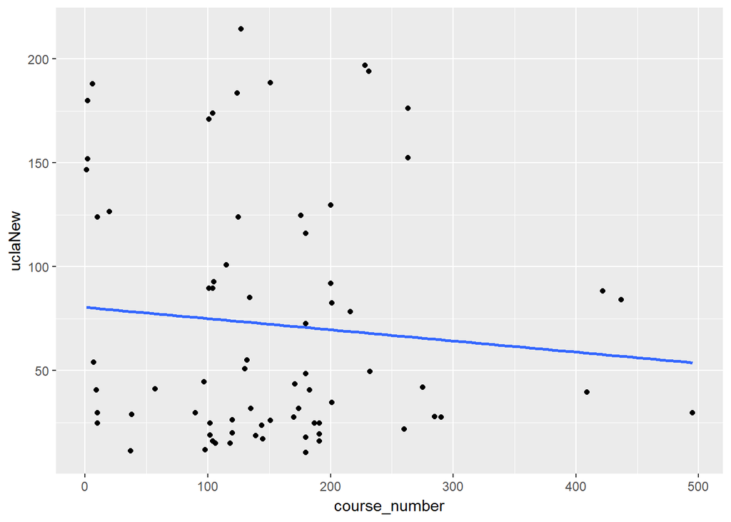

```r
#view textbook price versus course level
textbooks %>%
        mutate(course_number = readr::parse_number(course)) %>%
        ggplot(aes(x = course_number,
               y = uclaNew)) +
        geom_point() +
        geom_smooth(method = "lm",
                   se = FALSE)
```

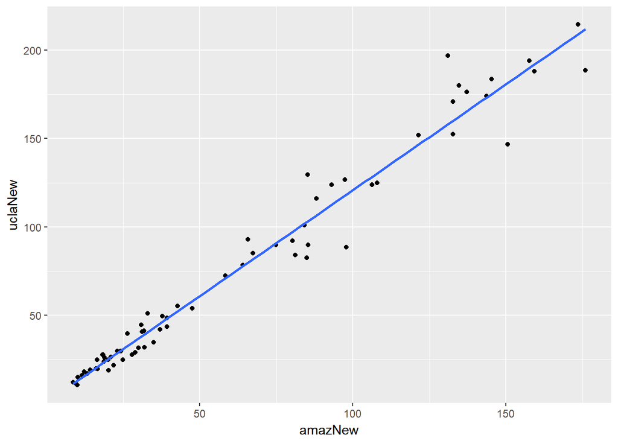

```r
#weak almost negative relationship
#so compare UCLA prices to Amazon Prices
textbooks %>%
        ggplot(aes(x = amazNew,
               y = uclaNew)) +
        geom_point() +
        geom_smooth(method = "lm",
                   se = FALSE)
```

```r
#much stronger positive, linear relationship
#good but does include coefficients
#Use the linear model function to actually fit the model and extract the coefficients
lm(formula = uclaNew ~ amazNew, data = textbooks)
```

```
##
## Call:
## lm(formula = uclaNew ~ amazNew, data = textbooks)
##
## Coefficients:
## (Intercept)      amazNew
##       0.929        1.199
```

```r
#lm(response ~ explanatory, data = X)
#With 0.929 (beta_hat_0) as the intercept and 1.199 as the slope (beta_hat_1)
#so for every $0.929 that Amazon charges - UCLA charges $1.199
#or UCLA prices are about 20% higher than Amazon
```

$\widehat{uclaNew}$ = 0.929 + 1.199 * amazNew

## Fitting simple linear models

While the geom_smooth(method = “lm”) function is useful for drawing linear models on a scatterplot, it doesn’t actually return the characteristics of the model. As suggested by that syntax, however, the function that creates linear models is lm(). This function generally takes two arguments:

A formula that specifies the model A data argument for the data frame that contains the data you want to use to fit the model The lm() function return a model object having class “lm”. This object contains lots of information about your regression model, including the data used to fit the model, the specification of the model, the fitted values and residuals, etc.

Instructions 100 XP Using the bdims dataset, create a linear model for the weight of people as a function of their height. Using the mlbBat10 dataset, create a linear model for SLG as a function of OBP. Using the mammals dataset, create a linear model for the body weight of mammals as a function of their brain weight, after taking the natural log of both variables.

```r
data(bdims)
glimpse(bdims)
```

```
## Observations: 507
## Variables: 25
## $ bia.di <dbl> 42.9, 43.7, 40.1, 44.3, 42.5, 43.3, 43.5, 44.4, 43.5, 4...
## $ bii.di <dbl> 26.0, 28.5, 28.2, 29.9, 29.9, 27.0, 30.0, 29.8, 26.5, 2...
## $ bit.di <dbl> 31.5, 33.5, 33.3, 34.0, 34.0, 31.5, 34.0, 33.2, 32.1, 3...
## $ che.de <dbl> 17.7, 16.9, 20.9, 18.4, 21.5, 19.6, 21.9, 21.8, 15.5, 2...
## $ che.di <dbl> 28.0, 30.8, 31.7, 28.2, 29.4, 31.3, 31.7, 28.8, 27.5, 2...
## $ elb.di <dbl> 13.1, 14.0, 13.9, 13.9, 15.2, 14.0, 16.1, 15.1, 14.1, 1...
## $ wri.di <dbl> 10.4, 11.8, 10.9, 11.2, 11.6, 11.5, 12.5, 11.9, 11.2, 1...
## $ kne.di <dbl> 18.8, 20.6, 19.7, 20.9, 20.7, 18.8, 20.8, 21.0, 18.9, 2...
## $ ank.di <dbl> 14.1, 15.1, 14.1, 15.0, 14.9, 13.9, 15.6, 14.6, 13.2, 1...
## $ sho.gi <dbl> 106.2, 110.5, 115.1, 104.5, 107.5, 119.8, 123.5, 120.4,...
## $ che.gi <dbl> 89.5, 97.0, 97.5, 97.0, 97.5, 99.9, 106.9, 102.5, 91.0,...
## $ wai.gi <dbl> 71.5, 79.0, 83.2, 77.8, 80.0, 82.5, 82.0, 76.8, 68.5, 7...
## $ nav.gi <dbl> 74.5, 86.5, 82.9, 78.8, 82.5, 80.1, 84.0, 80.5, 69.0, 8...
## $ hip.gi <dbl> 93.5, 94.8, 95.0, 94.0, 98.5, 95.3, 101.0, 98.0, 89.5, ...
## $ thi.gi <dbl> 51.5, 51.5, 57.3, 53.0, 55.4, 57.5, 60.9, 56.0, 50.0, 5...
## $ bic.gi <dbl> 32.5, 34.4, 33.4, 31.0, 32.0, 33.0, 42.4, 34.1, 33.0, 3...
## $ for.gi <dbl> 26.0, 28.0, 28.8, 26.2, 28.4, 28.0, 32.3, 28.0, 26.0, 2...
## $ kne.gi <dbl> 34.5, 36.5, 37.0, 37.0, 37.7, 36.6, 40.1, 39.2, 35.5, 3...
## $ cal.gi <dbl> 36.5, 37.5, 37.3, 34.8, 38.6, 36.1, 40.3, 36.7, 35.0, 3...
## $ ank.gi <dbl> 23.5, 24.5, 21.9, 23.0, 24.4, 23.5, 23.6, 22.5, 22.0, 2...
## $ wri.gi <dbl> 16.5, 17.0, 16.9, 16.6, 18.0, 16.9, 18.8, 18.0, 16.5, 1...
## $ age    <int> 21, 23, 28, 23, 22, 21, 26, 27, 23, 21, 23, 22, 20, 26,...
## $ wgt    <dbl> 65.6, 71.8, 80.7, 72.6, 78.8, 74.8, 86.4, 78.4, 62.0, 8...
## $ hgt    <dbl> 174.0, 175.3, 193.5, 186.5, 187.2, 181.5, 184.0, 184.5,...
## $ sex    <int> 1, 1, 1, 1, 1, 1, 1, 1, 1, 1, 1, 1, 1, 1, 1, 1, 1, 1, 1...
```

```r
lm(wgt ~ hgt, data = bdims)
```

```
##
## Call:
## lm(formula = wgt ~ hgt, data = bdims)
##
## Coefficients:
## (Intercept)          hgt
##    -105.011        1.018
```

```r
data("mlbBat10")
glimpse(mlbBat10)
```

```
## Observations: 1,199
## Variables: 19
## $ name     <fctr> I Suzuki, D Jeter, M Young, J Pierre, R Weeks, M Scu...
## $ team     <fctr> SEA, NYY, TEX, CWS, MIL, BOS, BAL, MIN, NYY, CIN, MI...
## $ position <fctr> OF, SS, 3B, OF, 2B, SS, OF, OF, 2B, 2B, OF, OF, 2B, ...
## $ G        <dbl> 162, 157, 157, 160, 160, 150, 160, 153, 160, 155, 157...
## $ AB       <dbl> 680, 663, 656, 651, 651, 632, 629, 629, 626, 626, 619...
## $ R        <dbl> 74, 111, 99, 96, 112, 92, 79, 85, 103, 100, 101, 103,...
## $ H        <dbl> 214, 179, 186, 179, 175, 174, 187, 166, 200, 172, 188...
## $ `2B`     <dbl> 30, 30, 36, 18, 32, 38, 45, 24, 41, 33, 45, 34, 41, 2...
## $ `3B`     <dbl> 3, 3, 3, 3, 4, 0, 3, 10, 3, 5, 1, 10, 4, 3, 3, 1, 5, ...
## $ HR       <dbl> 6, 10, 21, 1, 29, 11, 12, 3, 29, 18, 25, 4, 10, 25, 1...
## $ RBI      <dbl> 43, 67, 91, 47, 83, 56, 60, 58, 109, 59, 103, 41, 75,...
## $ TB       <dbl> 268, 245, 291, 206, 302, 245, 274, 219, 334, 269, 310...
## $ BB       <dbl> 45, 63, 50, 45, 76, 53, 73, 60, 57, 46, 56, 47, 28, 4...
## $ SO       <dbl> 86, 106, 115, 47, 184, 71, 93, 74, 77, 83, 105, 170, ...
## $ SB       <dbl> 42, 18, 4, 68, 11, 5, 7, 26, 3, 16, 14, 27, 14, 18, 1...
## $ CS       <dbl> 9, 5, 2, 18, 4, 4, 2, 4, 2, 12, 3, 6, 4, 9, 5, 1, 3, ...
## $ OBP      <dbl> 0.359, 0.340, 0.330, 0.341, 0.366, 0.333, 0.370, 0.33...
## $ SLG      <dbl> 0.394, 0.370, 0.444, 0.316, 0.464, 0.388, 0.436, 0.34...
## $ AVG      <dbl> 0.315, 0.270, 0.284, 0.275, 0.269, 0.275, 0.297, 0.26...
```

```r
lm(SLG ~ OBP, data = mlbBat10)
```

```
##
## Call:
## lm(formula = SLG ~ OBP, data = mlbBat10)
##
## Coefficients:
## (Intercept)          OBP
##    0.009407     1.110323
```

```r
data(mammals)
glimpse(mammals)
```

```
## Observations: 62
## Variables: 11
## $ Species     <fctr> Africanelephant, Africangiantpouchedrat, ArcticFo...
## $ BodyWt      <dbl> 6654.000, 1.000, 3.385, 0.920, 2547.000, 10.550, 0...
## $ BrainWt     <dbl> 5712.0, 6.6, 44.5, 5.7, 4603.0, 179.5, 0.3, 169.0,...
## $ NonDreaming <dbl> NA, 6.3, NA, NA, 2.1, 9.1, 15.8, 5.2, 10.9, 8.3, 1...
## $ Dreaming    <dbl> NA, 2.0, NA, NA, 1.8, 0.7, 3.9, 1.0, 3.6, 1.4, 1.5...
## $ TotalSleep  <dbl> 3.3, 8.3, 12.5, 16.5, 3.9, 9.8, 19.7, 6.2, 14.5, 9...
## $ LifeSpan    <dbl> 38.6, 4.5, 14.0, NA, 69.0, 27.0, 19.0, 30.4, 28.0,...
## $ Gestation   <dbl> 645, 42, 60, 25, 624, 180, 35, 392, 63, 230, 112, ...
## $ Predation   <int> 3, 3, 1, 5, 3, 4, 1, 4, 1, 1, 5, 5, 2, 5, 1, 2, 2,...
## $ Exposure    <int> 5, 1, 1, 2, 5, 4, 1, 5, 2, 1, 4, 5, 1, 5, 1, 2, 2,...
## $ Danger      <int> 3, 3, 1, 3, 4, 4, 1, 4, 1, 1, 4, 5, 2, 5, 1, 2, 2,...
```

```r
lm(log(BodyWt) ~ log(BrainWt), data = mammals)
```

```
##
## Call:
## lm(formula = log(BodyWt) ~ log(BrainWt), data = mammals)
##
## Coefficients:
##  (Intercept)  log(BrainWt)
##       -2.509         1.225
```

## Working with the linear model

class of the object from lm is a linear model the coef function extracts just the coefficients from the model the summary function provides all of the detailed information about the model the fitted.values returns (usually the same number of data points as records - eliminates missing values) Each fitted value generates a residual- difference between observed and expected response

```r
data("textbooks")
mod <- lm(uclaNew ~ amazNew, data = textbooks)
class(mod)
```

```
## [1] "lm"
```

```r
coef(mod)
```

```
## (Intercept)     amazNew
##   0.9289651   1.1990014
```

```r
summary(mod)
```

```
##
## Call:
## lm(formula = uclaNew ~ amazNew, data = textbooks)
##
## Residuals:
##     Min      1Q  Median      3Q     Max
## -34.785  -4.574   0.577   4.012  39.002
##
## Coefficients:
##             Estimate Std. Error t value Pr(>|t|)
## (Intercept)  0.92897    1.93538    0.48    0.633
## amazNew      1.19900    0.02519   47.60   <2e-16 ***
## ---
## Signif. codes:  0 '***' 0.001 '**' 0.01 '*' 0.05 '.' 0.1 ' ' 1
##
## Residual standard error: 10.47 on 71 degrees of freedom
## Multiple R-squared:  0.9696, Adjusted R-squared:  0.9692
## F-statistic:  2266 on 1 and 71 DF,  p-value: < 2.2e-16
```

```r
fitted.values(mod)
```

```
##         1         2         3         4         5         6         7
##  34.44105  38.26587  39.29701  14.74146  17.96678  13.12281  24.98093
##         8         9        10        11        12        13        14
##  20.90433 128.32287  16.82772  36.83906 106.54900  23.05054  20.67652
##        15        16        17        18        19        20        21
## 117.68772  57.89352  90.77014 160.12038 146.60764 130.42112  14.92131
##        22        23        24        25        26        27        28
##  23.63805  15.60474  27.24705  38.26587  35.64006  20.29284  46.19127
##        29        30        31        32        33        34        35
##  39.03323  40.46004  37.94214 102.84409  42.83406 118.37115  98.26390
##        36        37        38        39        40        41        42
##  12.31948  13.15878 162.42247 173.28542 211.95321 181.53455 175.26377
##        43        44        45        46        47        48        49
## 209.02765 157.99815 189.98751 165.39599  30.84405 191.90591  28.58993
##        50        51        52        53        54        55        56
##  26.15595  52.10235  48.13365 103.08389 112.59197  81.74166 160.14436
##        57        58        59        60        61        62        63
##  30.07669  30.84405 103.38364  13.01490  79.73933 101.95682  11.24038
##        64        65        66        67        68        69        70
##  70.97463  97.29271  77.77297  45.33998  25.16078  48.09768  32.54663
##        71        72        73
##  29.93281  23.37427  22.77477
```

```r
residuals(mod)
```

```
##            1            2            3            4            5
##  -6.77105468   2.32413081  -7.61701041   1.25853860   0.98322479
##            6            7            8            9           10
##   1.82719051  -0.28093350  -1.40432868  -4.48286560   0.17227613
##           11           12           13           14           15
##  -5.20905751   9.45100013   4.61945878   4.02348159   8.98227697
##           16           17           18           19           20
##  -3.99352239  -1.04014123  10.87961683   5.39236280  -5.62111808
##           21           22           23           24           25
##   1.07868839   2.31194809   2.39525758  -5.51704618   2.32413081
##           26           27           28           29           30
##  -6.69005609  -0.34283796   3.25873144   2.05676990  10.48995821
##           31           32           33           34           35
##   6.55786119 -20.39408550  -8.23406459 -29.95115384 -14.26390008
##           36           37           38           39           40
##  -1.06947854   1.84122047  17.60753411   0.71458128 -23.37321441
##           41           42           43           44           45
## -34.78454847   8.48622894   5.47234904  39.00184934   4.01249154
##           46           47           48           49           50
##  10.85401060  -6.14405043  -3.90591073   1.11007224   0.08404511
##           51           52           53           54           55
##   3.02765446  -4.57365085  26.51611422  11.24803299   3.37833944
##           56           57           58           59           60
##  -7.66436320  -0.37668952  -6.14405043 -13.67363613  -2.51489936
##           61           62           63           64           65
##  13.14067180  -1.07682445   0.70962274   1.49537216  -5.19270894
##           66           67           68           69           70
##   0.57703413  -3.33997755  -6.41078371   0.36231919   7.00336756
##           71           72           73
##  -0.28280935   0.38572840   4.92522911
```

```r
#augment from the broom package(part of tidyr) returns a data frame with original and fitted values, along with residuals and
#other statistical features of the model
augment(mod)
```

```
##    uclaNew amazNew   .fitted  .se.fit       .resid       .hat    .sigma
## 1    27.67   27.95  34.44105 1.460257  -6.77105468 0.01944321 10.515199
## 2    40.59   31.14  38.26587 1.418184   2.32413081 0.01833896 10.543185
## 3    31.68   32.00  39.29701 1.407411  -7.61701041 0.01806141 10.506820
## 4    16.00   11.52  14.74146 1.720649   1.25853860 0.02699567 10.545810
## 5    18.95   14.21  17.96678 1.673789   0.98322479 0.02554530 10.546241
## 6    14.95   10.17  13.12281 1.744683   1.82719051 0.02775510 10.544587
## 7    24.70   20.06  24.98093 1.577134  -0.28093350 0.02268020 10.546858
## 8    19.50   16.66  20.90433 1.632387  -1.40432868 0.02429719 10.545543
## 9   123.84  106.25 128.32287 1.700434  -4.48286560 0.02636508 10.532925
## 10   17.00   13.26  16.82772 1.690176   0.17227613 0.02604795 10.546892
## 11   31.63   29.95  36.83906 1.433496  -5.20905751 0.01873712 10.528168
## 12  116.00   88.09 106.54900 1.422121   9.45100013 0.01844092 10.485102
## 13   27.67   18.45  23.05054 1.602965   4.61945878 0.02342922 10.532103
## 14   24.70   16.47  20.67652 1.635552   4.02348159 0.02439150 10.535669
```

[output cut: 133 more lines]

## The lm summary output

An “lm” object contains a host of information about the regression model that you fit. There are various ways of extracting different pieces of information.

The coef() function displays only the values of the coefficients. Conversely, the summary() function displays not only that information, but a bunch of other information, including the associated standard error and p-value for each coefficient, the R2, adjusted R2, and the residual standard error. The summary of an “lm” object in R is very similar to the output you would see in other statistical computing environments (e.g. Stata, SPSS, etc.)

Instructions 100 XP We have already created the mod object, a linear model for the weight of individuals as a function of their height, using the bdims dataset and the code

mod <- lm(wgt ~ hgt, data = bdims) Now, you will:

Use coef() to display the coefficients of mod. Use summary() to display the full regression output of mod.

```r
data(bdims)
mod <- lm(wgt ~ hgt, data = bdims)
# Show the coefficients
coef(mod)
```

```
## (Intercept)         hgt
## -105.011254    1.017617
```

```r
# Show the full output
summary(mod)
```

```
##
## Call:
## lm(formula = wgt ~ hgt, data = bdims)
##
## Residuals:
##     Min      1Q  Median      3Q     Max
## -18.743  -6.402  -1.231   5.059  41.103
##
## Coefficients:
##               Estimate Std. Error t value Pr(>|t|)
## (Intercept) -105.01125    7.53941  -13.93   <2e-16 ***
## hgt            1.01762    0.04399   23.14   <2e-16 ***
## ---
## Signif. codes:  0 '***' 0.001 '**' 0.01 '*' 0.05 '.' 0.1 ' ' 1
##
## Residual standard error: 9.308 on 505 degrees of freedom
## Multiple R-squared:  0.5145, Adjusted R-squared:  0.5136
## F-statistic: 535.2 on 1 and 505 DF,  p-value: < 2.2e-16
```

## Fitted values and residuals

Once you have fit a regression model, you are often interested in the fitted values ($\hat{y_i}$) and the residuals ($e_i$), where $i$ indexes the observations. Recall that:

The least squares fitting procedure guarantees that the mean of the residuals is zero (n.b., numerical instability may result in the computed values not being exactly zero). At the same time, the mean of the fitted values must equal the mean of the response variable.

In this exercise, we will confirm these two mathematical facts by accessing the fitted values and residuals with the fitted.values() and residuals() functions, respectively, for the following model:

mod <- lm(wgt ~ hgt, data = bdims) Instructions 100 XP mod (defined above) is available in your workspace.

Confirm that the mean of the body weights equals the mean of the fitted values of mod. Compute the mean of the residuals of mod.

```r
data(bdims)

mod <- lm(wgt ~ hgt, data = bdims)
# Mean of weights equal to mean of fitted values?
mean(bdims$wgt, NA.RM = TRUE) == mean(fitted.values(mod), NA.RM = TRUE)
```

```
## [1] TRUE
```

```r
# Mean of the residuals
mean(residuals(mod))
```

```
## [1] -3.265933e-16
```

## Tidying your linear model

As you fit a regression model, there are some quantities (e.g. $R^2$) that apply to the model as a whole, while others apply to each observation (e.g. $\hat{y_i}$). If there are several of these per-observation quantities, it is sometimes convenient to attach them to the original data as new variables.

The augment() function from the broom package does exactly this. It takes a model object as an argument and returns a data frame that contains the data on which the model was fit, along with several quantities specific to the regression model, including the fitted values, residuals, leverage scores, and standardized residuals.

Instructions 100 XP The same linear model from the last exercise, mod, is available in your workspace.

Load the broom package. Create a new data frame called bdims_tidy that is the augmentation of the mod linear model. View the bdims_tidy data frame using glimpse().

```r
data(bdims)

mod <- lm(wgt ~ hgt, data = bdims)

# Load broom
library(broom)

# Create bdims_tidy
bdims_tidy <- mod %>% augment

# Glimpse the resulting data frame
glimpse(bdims_tidy)
```

```
## Observations: 507
## Variables: 9
## $ wgt        <dbl> 65.6, 71.8, 80.7, 72.6, 78.8, 74.8, 86.4, 78.4, 62....
## $ hgt        <dbl> 174.0, 175.3, 193.5, 186.5, 187.2, 181.5, 184.0, 18...
## $ .fitted    <dbl> 72.05406, 73.37697, 91.89759, 84.77427, 85.48661, 7...
## $ .se.fit    <dbl> 0.4320546, 0.4520060, 1.0667332, 0.7919264, 0.81834...
## $ .resid     <dbl> -6.4540648, -1.5769666, -11.1975919, -12.1742745, -...
## $ .hat       <dbl> 0.002154570, 0.002358152, 0.013133942, 0.007238576,...
## $ .sigma     <dbl> 9.312824, 9.317005, 9.303732, 9.301360, 9.312471, 9...
## $ .cooksd    <dbl> 5.201807e-04, 3.400330e-05, 9.758463e-03, 6.282074e...
## $ .std.resid <dbl> -0.69413418, -0.16961994, -1.21098084, -1.31269063,...
```

## Examining Residuals

```r
library(broom)
data("textbooks")
mod <- lm(uclaNew ~ amazNew, data = textbooks)
augment(mod) %>%
        arrange(desc(.resid)) %>%
        head()
```

```
##   uclaNew amazNew   .fitted  .se.fit   .resid       .hat    .sigma
## 1  197.00  131.00 157.99815 2.179394 39.00185 0.04330931  9.408665
## 2  129.60   85.20 103.08389 1.386624 26.51611 0.01753183 10.050561
## 3  180.03  134.69 162.42247 2.256857 17.60753 0.04644271 10.324375
## 4   92.88   65.73  79.73933 1.235832 13.14067 0.01392606 10.427641
## 5  123.84   93.13 112.59197 1.490523 11.24803 0.02025756 10.459091
## 6  171.00  132.77 160.12038 2.216402 10.87962 0.04479266 10.462654
##      .cooksd .std.resid
## 1 0.32816195   3.807626
## 2 0.05822235   2.554497
## 3 0.07219393   1.721789
## 4 0.01127520   1.263623
## 5 0.01217296   1.085114
## 6 0.02649222   1.062967
```

## Making predictions

The fitted.values() function or the augment()-ed data frame provides us with the fitted values for the observations that were in the original data. However, once we have fit the model, we may want to compute expected values for observations that were not present in the data on which the model was fit. These types of predictions are called out-of-sample.

The ben data frame contains a height and weight observation for one person. The mod object contains the fitted model for weight as a function of height for the observations in the bdims dataset. We can use the predict() function to generate expected values for the weight of new individuals. We must pass the data frame of new observations through the newdata argument.

Instructions 100 XP The same linear model, mod, is defined in your workspace.

```r
data(bdims)

mod <- lm(wgt ~ hgt, data = bdims)

wgt_Ben <- 74.8
hgt_Ben <- 182.8
Ben <- data.frame("wgt" = wgt_Ben, "hgt" = hgt_Ben)

print(Ben)
```

```
##    wgt   hgt
## 1 74.8 182.8
```

```r
predict(mod, newdata = Ben)
```

```
##        1
## 81.00909
```

## Adding a regression line to a plot manually

The geom_smooth() function makes it easy to add a simple linear regression line to a scatterplot of the corresponding variables. And in fact, there are more complicated regression models that can be visualized in the data space with geom_smooth(). However, there may still be times when we will want to add regression lines to our scatterplot manually. To do this, we will use the geom_abline() function, which takes slope and intercept arguments. Naturally, we have to compute those values ahead of time, but we already saw how to do this (e.g. using coef()).

The coefs data frame contains the model estimates retrieved from coef(). Passing this to geom_abline() as the data argument will enable you to draw a straight line on your scatterplot.

Instructions 100 XP Use geom_abline() to add a line defined in the coefs data frame to a scatterplot of weight vs. height for individuals in the bdims dataset.

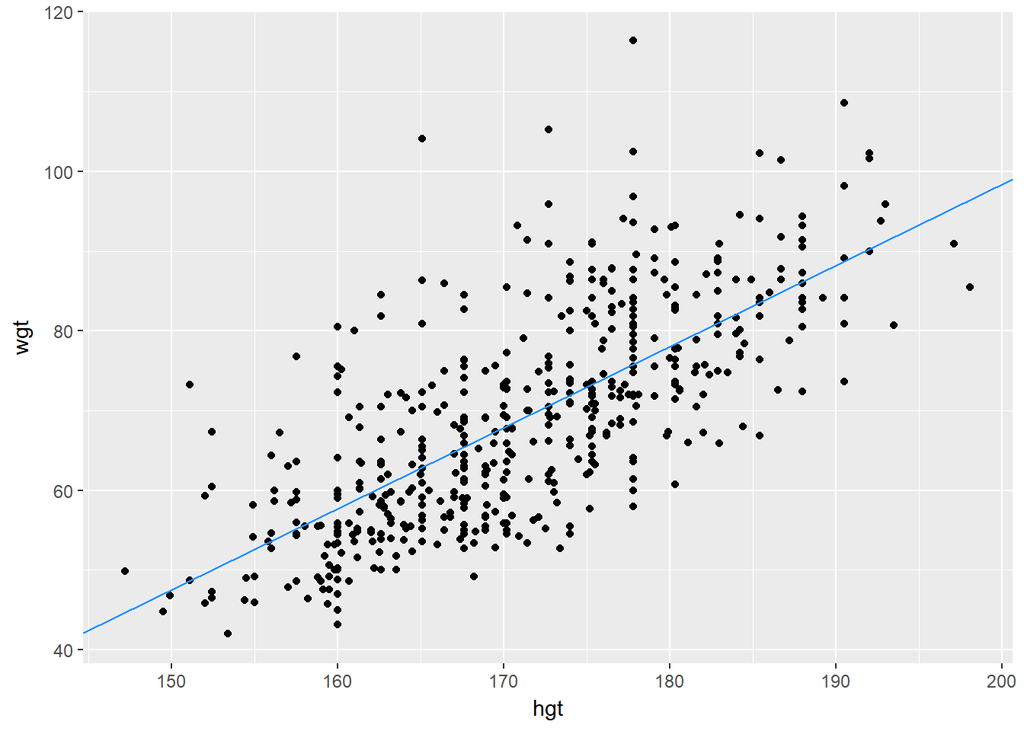

```r
# Add the line to the scatterplot

coefs <- tibble("(Intercept)" = -105.113, "hgt" = 1.017617)
ggplot(data = bdims, aes(x = hgt, y = wgt)) +
  geom_point() +
  geom_abline(data = coefs,
              aes(intercept = `(Intercept)`, slope = hgt),
              color = "dodgerblue")
```

## Assessing Model Fit

Least squares - sum of square deviations - minimize residuals - not the sum of the residuals (which is always 0)

SSE - sum of squared error

or use RMSE - root mean squared error $RMSE = \sqrt{\frac{\sum_ie^2_i}{d.f}} = \sqrt{\frac{SSE}{n - 2}}$

essentially the standard deviation of the residuals where $n-2$ represents the degrees of freedom

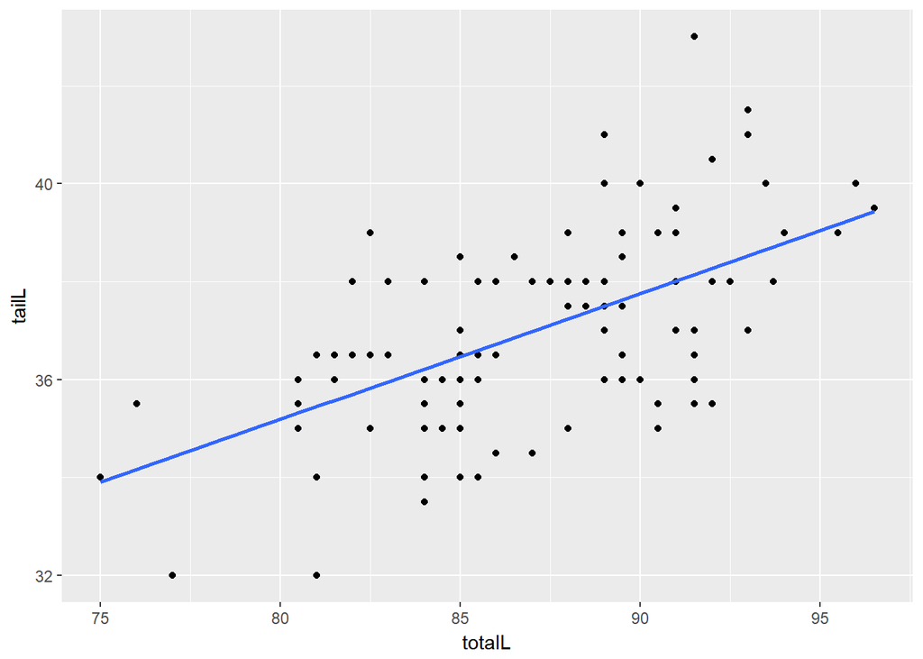

```r
data(possum)
possum %>% ggplot(aes(x = totalL,
                      y = tailL)) +
        geom_point() +
        geom_smooth(method = "lm", se = FALSE)
```

```r
mod_possum <- lm(totalL ~ tailL, data = possum)
mod_possum %>%
        augment() %>%
        summarize(SSE = sum(.resid^2),
                  SSE_also = (n() - 1) * var(.resid))
```

```
##        SSE SSE_also
## 1 1301.488 1301.488
```

```r
summary(mod_possum)
```

```
##
## Call:
## lm(formula = totalL ~ tailL, data = possum)
##
## Residuals:
##     Min      1Q  Median      3Q     Max
## -9.2100 -2.3265  0.1792  2.7765  6.7900
##
## Coefficients:
##             Estimate Std. Error t value Pr(>|t|)
## (Intercept)  41.0371     6.6568   6.165 1.43e-08 ***
## tailL         1.2443     0.1796   6.927 3.94e-10 ***
## ---
## Signif. codes:  0 '***' 0.001 '**' 0.01 '*' 0.05 '.' 0.1 ' ' 1
##
## Residual standard error: 3.572 on 102 degrees of freedom
## Multiple R-squared:   0.32,  Adjusted R-squared:  0.3133
## F-statistic: 47.99 on 1 and 102 DF,  p-value: 3.935e-10
```

The summary returns the ‘Residual standard error’, which is the RMSE - so for the example - the model predicts a body length within 3.572 centimeters of real observations

## Standard error of residuals

One way to assess strength of fit is to consider how far off the model is for a typical case. That is, for some observations, the fitted value will be very close to the actual value, while for others it will not. The magnitude of a typical residual can give us a sense of generally how close our estimates are.

However, recall that some of the residuals are positive, while others are negative. In fact, it is guaranteed by the least squares fitting procedure that the mean of the residuals is zero. Thus, it makes more sense to compute the square root of the mean squared residual, or root mean squared error (RMSE). R calls this quantity the residual standard error.

To make this estimate unbiased, you have to divide the sum of the squared residuals by the degrees of freedom in the model. Thus,

$RMSE = \sqrt{\frac{\sum_ie^2_i}{d.f}} = \sqrt{\frac{SSE}{n - 2}}$ You can recover the residuals from mod with residuals(), and the degrees of freedom with df.residual().

Instructions 100 XP View a summary() of mod. Compute the mean of the residuals() and verify that it is approximately zero. Use residuals() and df.residual() to compute the root mean squared error (RMSE), a.k.a. residual standard error.

```r
data(bdims)
mod <- lm(wgt ~ hgt, data = bdims)
summary(mod)
```

```
##
## Call:
## lm(formula = wgt ~ hgt, data = bdims)
##
## Residuals:
##     Min      1Q  Median      3Q     Max
## -18.743  -6.402  -1.231   5.059  41.103
##
## Coefficients:
##               Estimate Std. Error t value Pr(>|t|)
## (Intercept) -105.01125    7.53941  -13.93   <2e-16 ***
## hgt            1.01762    0.04399   23.14   <2e-16 ***
## ---
## Signif. codes:  0 '***' 0.001 '**' 0.01 '*' 0.05 '.' 0.1 ' ' 1
##
## Residual standard error: 9.308 on 505 degrees of freedom
## Multiple R-squared:  0.5145, Adjusted R-squared:  0.5136
## F-statistic: 535.2 on 1 and 505 DF,  p-value: < 2.2e-16
```

```r
mean(residuals(mod))
```

```
## [1] -3.265933e-16
```

```r
df.residual(mod)
```

```
## [1] 505
```

```r
# View summary of model
summary(mod)
```

```
##
## Call:
## lm(formula = wgt ~ hgt, data = bdims)
##
## Residuals:
##     Min      1Q  Median      3Q     Max
## -18.743  -6.402  -1.231   5.059  41.103
##
## Coefficients:
##               Estimate Std. Error t value Pr(>|t|)
## (Intercept) -105.01125    7.53941  -13.93   <2e-16 ***
## hgt            1.01762    0.04399   23.14   <2e-16 ***
## ---
## Signif. codes:  0 '***' 0.001 '**' 0.01 '*' 0.05 '.' 0.1 ' ' 1
##
## Residual standard error: 9.308 on 505 degrees of freedom
## Multiple R-squared:  0.5145, Adjusted R-squared:  0.5136
## F-statistic: 535.2 on 1 and 505 DF,  p-value: < 2.2e-16
```

```r
# Compute the mean of the residuals
mean(residuals(mod))
```

```
## [1] -3.265933e-16
```

```r
# Compute RMSE
sqrt(sum(residuals(mod)^2) / df.residual(mod))
```

```
## [1] 9.30804
```

## Comparing model fits

Null or average model indicates that the best expected value is the normal value  
$\hat{y} = \bar{y}$

```r
data(possum)
mod_possumNULL <- lm(totalL ~ 1, data = possum)
#augment from the broom package(part of tidyr) returns a data frame with original and fitted values, along with residuals and other statistical features of the model
mod_possumNULL %>%
        augment() %>%
        summarize(SST = sum(.resid^2))
```

```
##        SST
## 1 1913.826
```

```r
mod_possum <- lm(totalL ~ tailL, data = possum)
mod_possum %>%
        augment() %>%
        summarize(SSE = sum(.resid^2))
```

```
##        SSE
## 1 1301.488
```

The coefficient of determination of $R^2$

$R^2 = 1 - \frac{SSE}{SST} = 1 - \frac{Var(e)}{Var(y)}$

Ratio of SSE of our model to SST of null model is quantification of the variability explained by our model.

The SST (total sum of squares) from NULL model portion of SST not explained by model is the SSE or R^2 Interpret $R^2$ as proportion of variablility in response variable explained by the model - used as a measure of the quality of the fit of the model

Connection to Correlation -For simple linear regression $R^2$ is the square of the correlation coefficient $r^2_{x,y}$

$r^2_{x,y} = R^2$

## Assessing simple linear model fit

Recall that the coefficient of determination $(R^2)$, can be computed as $R^2 = 1 - \frac{SSE}{SST} = 1 - \frac{Var(e)}{Var(y)}$ where $e$ is the vector of residuals and $y$ is the response variable. This gives us the interpretation of $R^2$ as the percentage of the variability in the response that is explained by the model, since the residuals are the part of that variability that remains unexplained by the model.

Instructions 100 XP The bdims_tidy data frame is the result of augment()-ing the bdims data frame with the mod for wgt as a function of hgt.

Use the summary() function to view the full results of mod. Use the bdims_tidy data frame to compute the R2 of mod manually using the formula above, by computing the ratio of the variance of the residuals to the variance of the response variable.

```r
data(bdims)

mod <- lm(wgt ~ hgt, data = bdims)

# Load broom
library(broom)

# Create bdims_tidy
bdims_tidy <- mod %>% augment
# View model summary
summary(mod)
```

```
##
## Call:
## lm(formula = wgt ~ hgt, data = bdims)
##
## Residuals:
##     Min      1Q  Median      3Q     Max
## -18.743  -6.402  -1.231   5.059  41.103
##
## Coefficients:
##               Estimate Std. Error t value Pr(>|t|)
## (Intercept) -105.01125    7.53941  -13.93   <2e-16 ***
## hgt            1.01762    0.04399   23.14   <2e-16 ***
## ---
## Signif. codes:  0 '***' 0.001 '**' 0.01 '*' 0.05 '.' 0.1 ' ' 1
##
## Residual standard error: 9.308 on 505 degrees of freedom
## Multiple R-squared:  0.5145, Adjusted R-squared:  0.5136
## F-statistic: 535.2 on 1 and 505 DF,  p-value: < 2.2e-16
```

```r
# Compute R-squared
bdims_tidy %>%
  summarize(var_y = var(wgt), var_e = var(.resid)) %>%
  mutate(R_squared = 1 - (var_e/var_y))
```

```
##      var_y    var_e R_squared
## 1 178.1094 86.46839 0.5145208
```

## Interpretation of $R^2$

The $R^2$ reported for the regression model for poverty rate of U.S. counties in terms of high school graduation rate is 0.464.

```r
lm(formula = poverty ~ hs_grad, data = countyComplete) %>%
  summary()
```

```
##
## Call:
## lm(formula = poverty ~ hs_grad, data = countyComplete)
##
## Residuals:
##     Min      1Q  Median      3Q     Max
## -18.035  -3.034  -0.434   2.405  36.874
##
## Coefficients:
##             Estimate Std. Error t value Pr(>|t|)
## (Intercept) 64.59437    0.94619   68.27   <2e-16 ***
## hs_grad     -0.59075    0.01134  -52.09   <2e-16 ***
## ---
## Signif. codes:  0 '***' 0.001 '**' 0.01 '*' 0.05 '.' 0.1 ' ' 1
##
## Residual standard error: 4.677 on 3141 degrees of freedom
## Multiple R-squared:  0.4635, Adjusted R-squared:  0.4633
## F-statistic:  2713 on 1 and 3141 DF,  p-value: < 2.2e-16
```

How should this result be interpreted? 46.4% of the variability is explained by change in high school graduation rates

## Linear vs. average

The $R^2$ gives us a numerical measurement of the strength of fit relative to a null model based on the average of the response variable:  
$\hat{y}_{null} = \bar{y}$  
This model has an $R^2$ of zero because SSE=SST. That is, since the fitted values ($\hat{y}_{null}$) are all equal to the average ($\bar{y}$), the residual for each observation is the distance between that observation and the mean of the response. Since we can always fit the null model, it serves as a baseline against which all other models will be compared.

It may be useful to preview these augment()-ed data frames with glimpse():

glimpse(mod_null) glimpse(mod_hgt) Instructions 100 XP Compute the sum of the squared residuals (SSE) for the null model mod_null. Compute the sum of the squared residuals (SSE) for the regression model mod_hgt.

Compute SSE for null model mod_null %>% summarize(SSE = var(.resid))

Compute SSE for regression model mod_hgt %>% summarize(SSE = var(.resid))

## Unusual Points

Leverage

$h_i = \frac{1}{n} + \frac{(x_i - \bar{x})^2}{\sum_{i=1}^n(x_i - \bar{x})}$  
uses only the explanatory variable and the distance from the explanatory variable mean and Influence - points near horizontal center of scatterplot have low leverage - and further away = higher leverage

retrieve .hat from augment function to find leverage

the high leverage SB is probably not influential as the regression line passes close to the outlier anyways high leverage with high residual = influence - included as Cooks Distance in augment()

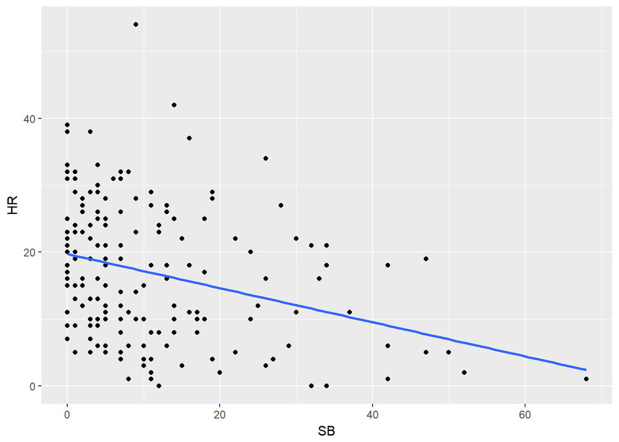

```r
data("mlbBat10")
regulars <- mlbBat10 %>%
        filter(AB > 400)
regulars %>% ggplot(aes(x = SB,
                        y = HR)) +
        geom_point() +
        geom_smooth(method = "lm", se = 0)
```

```r
mod <- lm(HR ~ SB, data = regulars)
mod %>% augment() %>%
        arrange(desc(.hat)) %>%
        select(HR, SB, .fitted, .resid, .hat) %>%
        head()
```

```
##   HR SB  .fitted    .resid       .hat
## 1  1 68 2.382748 -1.382748 0.13081869
## 2  2 52 6.461361 -4.461361 0.07033516
## 3  5 50 6.971187 -1.971187 0.06416940
## 4 19 47 7.735927 11.264073 0.05550188
## 5  5 47 7.735927 -2.735927 0.05550188
## 6  1 42 9.010493 -8.010493 0.04260564
```

## Leverage

The leverage of an observation in a regression model is defined entirely in terms of the distance of that observation from the mean of the explanatory variable. That is, observations close to the mean of the explanatory variable have low leverage, while observations far from the mean of the explanatory variable have high leverage. Points of high leverage may or may not be influential.

The augment() function from the broom package will add the leverage scores (.hat) to a model data frame.

Instructions 100 XP Use augment() to list the top 6 observations by their leverage scores, in descending order.

```r
mod %>%
        augment() %>%
        arrange(desc(.hat)) %>%
        head(6)
```

```
##   HR SB  .fitted  .se.fit    .resid       .hat   .sigma     .cooksd
## 1  1 68 2.382748 3.521029 -1.382748 0.13081869 9.763400 0.001746770
## 2  2 52 6.461361 2.581790 -4.461361 0.07033516 9.757507 0.008545844
## 3  5 50 6.971187 2.466032 -1.971187 0.06416940 9.762801 0.001502069
## 4 19 47 7.735927 2.293446 11.264073 0.05550188 9.722795 0.041648277
## 5  5 47 7.735927 2.293446 -2.735927 0.05550188 9.761644 0.002457056
## 6  1 42 9.010493 2.009409 -8.010493 0.04260564 9.743501 0.015736372
##   .std.resid
## 1 -0.1523538
## 2 -0.4753018
## 3 -0.2093122
## 4  1.1905845
## 5 -0.2891807
## 6 -0.8409674
```

## Influence

As noted previously, observations of high leverage may or may not be influential. The influence of an observation depends not only on its leverage, but also on the magnitude of its residual. Recall that while leverage only takes into account the explanatory variable (x), the residual depends on the response variable (y) and the fitted value (y^).

Influential points are likely to have high leverage and deviate from the general relationship between the two variables. We measure influence using Cook’s distance, which incorporates both the leverage and residual of each observation.

Instructions 100 XP Use augment() to list the top 6 observations by their Cook’s distance (.cooksd), in descending order.

```r
mod %>%
        augment() %>%
        arrange(desc(.cooksd)) %>%
        head(6)
```

```
##   HR SB   .fitted   .se.fit    .resid        .hat   .sigma    .cooksd
## 1 54  9 17.422632 0.7585705 36.577368 0.006071871 9.342206 0.04338485
## 2 19 47  7.735927 2.2934459 11.264073 0.055501875 9.722795 0.04164828
## 3 34 26 13.089106 1.1663584 20.910894 0.014354719 9.627079 0.03408782
## 4 42 14 16.148065 0.7655140 25.851935 0.006183536 9.555643 0.02207554
## 5 39  0 19.716851 1.0094490 19.283149 0.010752252 9.648127 0.02155489
## 6 18 42  9.010493 2.0094085  8.989507 0.042605645 9.738158 0.01981791
##   .std.resid
## 1  3.7687757
## 2  1.1905845
## 3  2.1636032
## 4  2.6638225
## 5  1.9915479
## 6  0.9437474
```